# 16 Survol conceptuel: La quantification de l’impact d’une variable sur une autre

- Montrer tout le code
- Cacher tout le code

Auteur

Affiliation

Daniel Coulombe

Institut des Sciences, Technologies et Études Avancées d’Haïti (ISTEAH)

Date

25/03/2024

Le présent chapitre est une introduction conceptuelle à la modélisation univariée. On y présente une variable dépendante unique, qui pourra être de nature qualitative (nominale ou ordinale) ou quantitative, que l’on relie à une ou plusieurs variables indépendantes qualitatives ou quantitatives.

Il s’agit d’un survol, sans discussion des fondements formels sous-jacents aux analyses. De ce faut, les formulations mathématiques sont réduites au strict minimum.

On utilise le logiciel R pour tous les calculs effectués sur les données simulées, et les codes utilisés sont disponibles. Cependant, il n’est nullement nécessaire de les considérer et de fait, ils sont cachés par défaut.

Pour les besoins du présent document et des concepts et procédures qui y sont présentés, la simulation de données sera omniprésente. Le code R utilisé pour générer les données s’affiche en cliquant sur la flèche, ci-dessous. Dès lors, on pourra aisément modifier le modèle initial, en spécifier un nouveau, et générer de nouvelles données, supposant R disponible.

```r
# Génération de données à partir d'un modèle linéaire

set.seed(9382757)
n <- 300              # Nombre d'observations

# Génération de données aléatoires
x1 <- rnorm(n, 20, 5)
x2 <- rnorm(n, 20, 5)
x3 <- rnorm(n, 20, 5)
x4 <- rnorm(n, 20, 5)
x5 <- (0.7 * scale(x4) + sqrt(1 - 0.7^2) * rnorm(n)) * 5 + 20

Genre <- sample(0:1, n,
                replace = TRUE,
                prob = c(0.4, 0.6))
d1 <- data.frame(x1, x2, x3, x4, x5, Genre)

d2 <- simstudy::genCorData(n,
                           mu = c(20, 20, 20),
                           sigma = c(5, 5, 5),
                           rho = 0.9,
                           corstr = "cs",
                           cnames = c("x6", "x7", "x8"))

# Modèle au niveau de la population
y <- 2.3 * d1$x1 + 0.001 * d1$x2 + 0.001 * d1$x3 + 2.5 * d1$x4 + 3 * d1$x5 + 20 * d1$Genre - 0.6 * d2$x6 - 0.5 * d2$x7 - 0.6 * d2$x8 + 6 * rnorm(n, 0, 8) + 100

my <- mean(y)
vy <- var(y)
dat <- cbind(y, d1, d2[, 2:4])

# Sauvegarde des données
misty::write.sav(dat,
                 file = "./data/dataset.sav",
                 digits = 5,
                 write.csv = TRUE,
                 sep = ",",
                 write.sps = TRUE)
xlsx::write.xlsx(dat,
                 "./data/dataset.xlsx",
                 sheetName = "Données",
                 row.names = FALSE)
foreign::write.dta(dat,
                   "./data/dataset.dta")
```

Les données générées sont affichées dans le tableau suivant, présentant les premières et dernières observations pour l’ensemble des variables qui seront sélectivement utilisées dans la définition des différents modèles présentés dans ce document. On pourra télécharger un fichier CSV contenant les données générées en cliquant sur le bouton, ci-dessous.

```r
dat %>%
  download_this(
    path = "./data/dataset.csv",
    output_name = "dataset",
    button_label = "Télécharger les données (.csv)",
    button_type = "success",
    has_icon = TRUE,
    icon = "fa fa-save"
  )
```

Finalement, les corrélations entre chaque paire de variables, prenant la forme d’une matrice, sont affichées dans la figure Figure 16.1:

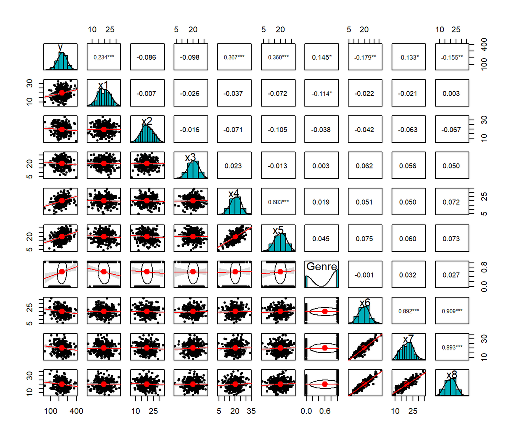

Figure 16.1: Matrice des corrélations (portion triangulaire supérieure) et des diagrammes de dispersion (portion triangulaire inférieure). La distribution des variables est illustrée dans la diagonale principale. La signification statistique des corrélations est indiquée par des astérisques: () p > 0.05, (*) p < 0.05, et (**) p < 0.01.

```r
psych::pairs.panels(dat,
                    method = "pearson",
                    hist.col = "#00AFBB",
                    density = TRUE,
                    ellipses = TRUE,
                    smooth = FALSE,
                    digits = 3,
                    lm = TRUE,
                    cex=0.8,
                    stars=TRUE,
                    ci = TRUE)
```

Cette matrice est de fait l’ingrédient de base de plusieurs procédures d’analyse quantitative.

## 16.1 Introduction: la Variance

Imaginons une mesure quantitative de la performance dans une tâche donnée. Nommons cette variable $y$, et supposons que cette mesure est valide et fiable. On évalue $y$ auprès de $n=300$ individus, et on obtient un ensemble de scores, dont les 10 premiers sont reproduits ci-dessous:

```r
round(head(y, 10), 2)
```

```
#>  [1] 335.89 225.66 294.04 289.73 251.49 376.08 287.95 196.34 230.71 259.97
```

On note que la performance varie d’un individu à l’autre. Cette variation est davantage manifeste lorsque ces données sont représentées dans un histogramme (Figure 16.2):

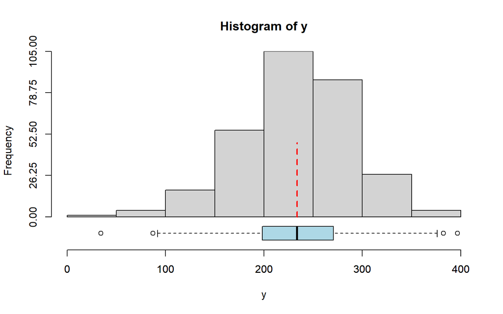

Figure 16.2: Distribution de la variable y (Performance)

```r
res <- hist(y,
            breaks = "FD",
            plot = FALSE)
fm <- max(res$counts)

hist_boxplot2(y)
#             freq = TRUE,
#             main = 'Distribution de la Performance',
#             xlab = 'Performance',
#             ylab = 'Fréquence',
#             col = 'lightblue',
#             breaks = 'FD')
segments(x0 = mean(y),
         y0 = 0,
         x1 = mean(y),
         y1 = fm,
         lty = 2,
         lwd = 2,
         col = "red")
```

Le centre de cette distribution est $\overline{y}=$ 233.632, valeur indiquée par la ligne verticale rouge dans l’histogramme. Cette moyenne représente la valeur de performance attendue d’un individu sélectionné au hasard. On peut aisément concevoir que toute déviation par rapport à cette valeur représente une *erreur*, ou une *valeur résiduelle*, ou tout simplement un *résidu*. Ces termes sont synonymes.  
Formellement, une valeur résiduelle observée pour l’individu *i* se définit par l’écart séparant $y_i$ de $\overline{y}$ (équation Équation 16.1):

$$e_i=y_i-\overline{y} \tag{16.1}$$

De façon générale, plus une erreur a une valeur élevée, plus la probabilité de l’observer est faible. Inversement, plus une erreur est rapprochée de la moyenne, plus elle est probable.

Afin de quantifier la variabilité ou le degré de dispersion d’une variable, les valeurs résiduelles sont considérées dans leur ensemble. Spécifiquement, on définira la variance d’une population comme étant la moyenne des carrés de ces valeurs (Équation 16.2):

$$\sigma^2=\frac{\sum\limits_{i=1}^N\epsilon_i^2}{N}=\frac{\sum\limits_{i=1}^n(y_i-\mu_y)^2}{N} \tag{16.2}$$
Pour un échantillon, une estimation non-biaisée de cette quantité s’obtient par l’équation Équation 16.3:

$$s^2=\frac{\sum\limits_{i=1}^ne_i^2}{n-1}=\frac{\sum\limits_{i=1}^n(y_i-\overline{y})^2}{n-1} \tag{16.3}$$

Dans cette équation, le numérateur correspond à $SC_y=$ Somme des Carrés, et le dénominateur au nombre de **degrés de liberté**, des termes qui sont omniprésents dans le contexte des analyses quantitatives.

On note que la contribution d’une observation à la variance est fonction de la distance qui la sépare de la moyenne. Des observations qui se concentrent près de la moyenne présenteront une contribution plus faible que des observations qui s’en éloignent. À la limite, la contribution d’une observation égale à la moyenne est nulle. La figure Figure 16.3 illustre clairement ce point.

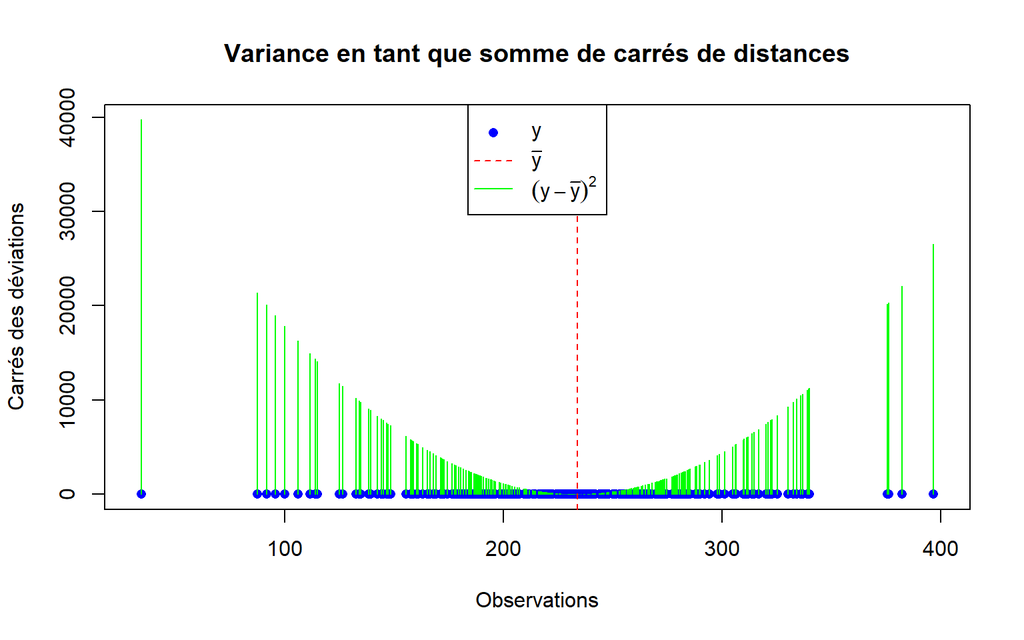

Figure 16.3: Les lignes verticales vertes sont les carrés des déviations par rapport à la moyenne (expression(y-bar(“Y))^2). La moyenne est représentée par la ligne verticale rouge. La moyenne de ces quantités correspond à la variance. On note que plus l’écart entre une donnée et la moyenne est grande, plus sa contribution à la valeur de la variance est importante. Les données situées près de la moyenne ne contribuent que peu à cette valeur.

```r
data <- y
mean_value <- mean(data)
squared_distances <- (data - mean_value)^2
variance <- sum(squared_distances) / (length(data) - 1)

plot(1,
     type = "n",
     xlim = c(min(data) - 2,
              max(data) + 2),
     ylim = c(-0.5, max(squared_distances) + 5),
     xlab = "Observations",
     ylab = "Carrés des déviations",
     main = "Variance en tant que somme de carrés de distances")

points(data,
       rep(0, length(data)),
       pch = 16,
       col = "blue")

abline(v = mean_value,
       col = "red",
       lty = 2)

for (i in seq_along(data)) {
  segments(data[i], 0, data[i], squared_distances[i], col = "green")
}

legend("top",
       legend = c("y", expression(bar("y")), expression((y-bar("y"))^2)),
       col = c("blue", "red", "green"),
       pch = c(16, NA, NA),
       lty = c(NA, 2, 1))
```

La nature de la variance, illustrée par la figure Figure 16.3, implique l’absence d’une unité de mesure pour cet indice de variabilité, En conséquence, elle ne se prête pas à une interprétation précise. Cependant, ceci ne réduit en rien son importance dans le contexte de recherches quantitatives.

On peut aisément imaginer que cette quantité résulte d’un nombre indéterminé de facteurs susceptibles d’influencer la performance. On pourrait sans doute mentionner la motivation de l’individu à exécuter la tâche requise, ses habiletés intellectuelles, certaines habiletés développées antérieurement, son niveau d’expérience, et une foule d’autres variables qu’on pourrait éventuellement évaluer. L’objectif général d’une recherche quantitative est de développer un modèle explicatif permettant d’attribuer à différents facteurs ou diverses variables une part de responsabilité dans la variation observée dans une variable dépendante.

## 16.2 Modèle nul

Le modèle le plus simple que l’on puisse proposer pour rendre compte de la variabilité de la variable dépendante prend la forme de l’équation Équation 16.4:

$$y_i=\mu_y+\epsilon_i \tag{16.4}$$

Ce modèle propose que la valeur de la performance d’un individu ($y_i$) réflète la performance moyenne au niveau de la population ($\mu_y$), à laquelle s’ajoute une variation aléatoire résultant d’influences non spécifiées ($\epsilon_i$). Dans les faits, ce modèle ne réflète que la prédiction de $y$ (variable dépendante) à partir d’une constante (par exemple, ‘1’). Il s’agit d’un modèle qualifié de *nul*, puisqu’il n’implique aucune information autre que les données elles-mêmes. La figure Figure 16.4 en est une représentation:

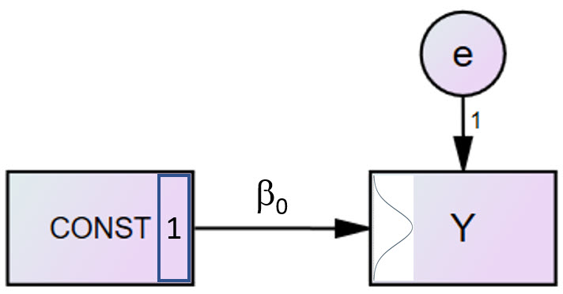

Figure 16.4: Modèle nul, n’impliquant aucune variable indépendante. Seule une constante est régressée sur la variable dépendante

Formellement, définissons ce modèle de la manière suivante:

$$\hat{y}=1\beta_0 + \epsilon$$
Spécifiquement, la valeur prédite de $y$ (notée $\hat{y}$), est égale à une constante ($\beta_0$), plus une erreur aléatoire.

Les paramètres de ce modèle sont:

1. $\beta_0$, estimé par $b_0$
2. La variance des erreurs ($\sigma_{\epsilon}^2$), estimé par $s_e^2$

Pour les données actuelles, on peut estimer ces paramètres à l’aide de la fonction lm():

```r
reg0 <- lm(y ~ 1)    # Régression d'une constante sur y
res_reg0 <- summary(reg0)

res_reg0
```

```
#>
#> Call:
#> lm(formula = y ~ 1)
#>
#> Residuals:
#>     Min      1Q  Median      3Q     Max
#> -199.34  -35.05   -0.08   37.01  163.01
#>
#> Coefficients:
#>             Estimate Std. Error t value Pr(>|t|)
#> (Intercept)  233.632      3.193   73.18   <2e-16 ***
#> ---
#> Signif. codes:  0 '***' 0.001 '**' 0.01 '*' 0.05 '.' 0.1 ' ' 1
#>
#> Residual standard error: 55.3 on 299 degrees of freedom
```

Le premier bloc de ces résultats fournit une description de la distribution des valeurs résiduelles, incluant les valeurs minimum et maximum, de même que les trois quartiles. Cette distribution semble symétrique autour de la médiane, qui environne 0. La moyenne des valeurs résiduelles sera toujours exactement nulle. La forme de cette distribution semble gaussienne, ce qui est un postulat important pour une analyse de ce type. La figure suivante en fournit une illustration:

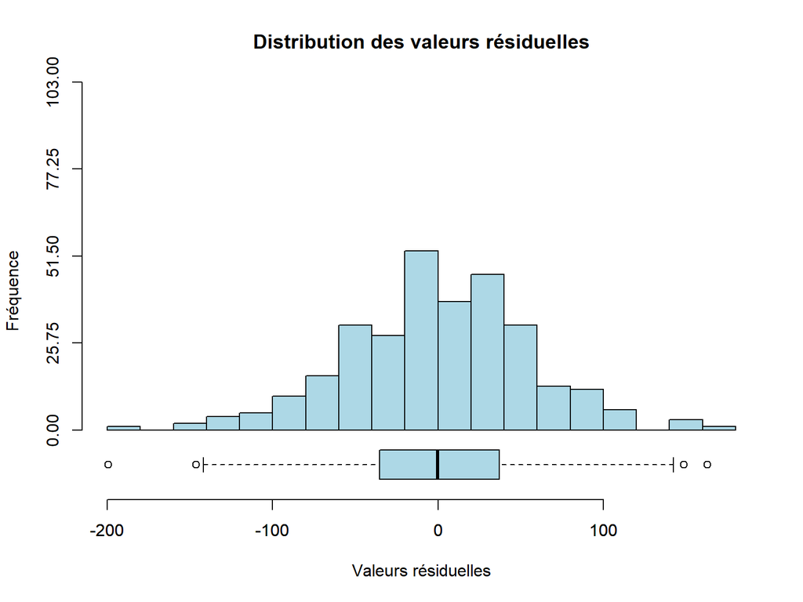

Figure 16.5: Distribution des valeurs résiduelles (simples écarts par rapport à la moyenne)

```r
resid0 <- residuals(res_reg0)

hist_boxplot2(resid0,
              main = "Distribution des valeurs résiduelles",
              ylab = "Fréquence",
              xlab = "Valeurs résiduelles",
              freq = TRUE,
              col = 'lightblue',
              breaks = 'FD')
```

Le second bloc de résultats est plus pertinent pour la présente discussion. Le coefficient obtenu (libellé *Intercept*) correspond à la valeur de $y$ en l’absence de toute information provenant d’autres variables. En d’autres termes, il s’agit de la valeur de la performance que l’on pourrait observer chez un individu choisi aléatoirement, si aucune information n’est prise en compte (le modèle ne fait appel à aucune variable indépendante). Sans surprise, cette valeur est égale à $\overline{y}$=233.632. Sur la même ligne, on peut lire que l’erreur-standard de cet intercept est 3.193, et le rapport entre l’estimé de l’intercept et son erreur-standard produit la statistique *t* permettant le test de signification approprié. Ici, l’hypothèse soumise au test propose que:

$$H_0:\beta_0=0 \quad \Leftrightarrow \quad H_0:\mu_y=0$$

Dans le cas présent, on trouve que la performance moyenne est significativement différente de 0, ce qui n’est en rien une surprise: $H_0$ n’est pas retenue. La figure suivante illustre la situation. Les observations sont représentées par le ‘tapis’ longeant l’axe horizontal. On peut apercevoir une forte concentration de cas autour de la moyenne (ligne verticale verte), et des densités décroissantes à l’approche des extrémités. En conséquence, en sélectionnant un individu au hasard, on peut s’attendre à ce que sa performance se trouve dans une zone avoisinant la moyenne.

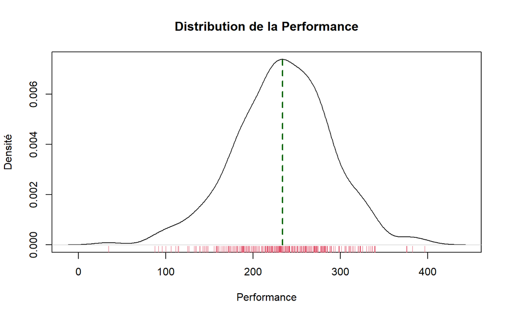

Figure 16.6: Répartition des observations et tracé de densité. La ligne verticale verte indique la position de la moyenne.

```r
densdat <- density(y)
plot(densdat,
     main = 'Distribution de la Performance',
     xlab = 'Performance',
     ylab = 'Densité')
rug(y,
    col = 2,
    lwd = 0.5)
segments(x0 = my, y0 = 0, x1 = my, y1 = max(densdat$y),
         lty = 2,
         col = 'darkgreen',
         lwd = 2)
```

Le second paramètre du modèle est la variance des erreurs. Cette variance est le carré de la quantité libelée *Residual standard error*:

$s_{\epsilon}^2=$ 55.297 $^2=$ 3057.774

En effet, en calculant directement la variance des valeurs résiduelles (obtenues à l’aide de la fonction **residuals()**, sous R), on trouve:

```r
resid <- residuals(res_reg0)
cat('Variance des erreurs = ', round(var(resid), 3))
```

```
#> Variance des erreurs =  3057.774
```

Puisqu’aucune variable indépendant n’est prise en compte, cette variance est de fait égale à la variance de la variable $y$:

```r
cat('Variance de Y = ', round(var(y), 3))
```

```
#> Variance de Y =  3057.774
```

On se retrouve donc dans une position où le modèle ne peut qu’estimer la moyenne de la variable étudié, et reproduire sa variance. Or, ce que l’on tente d’expliquer, c’est spécifiquement les sources de cette variation. Quels sont les facteurs présents chez un individu, faisant en sorte que sa performance soit plus faible ou plus élevée que la moyenne? Pour répondre à cette question, il faudra approfondir nos connaissances théoriques concernant le phénomène étudié, et déterminer certaines variables ou certains facteurs susceptibles d’être candidats aux postes de *prédicteurs* de la variable dépendante $y$.

Les prédicteurs susceptibles d’expliquer une certaine portion de la variance d’une variable dépendante quantitative peuvent être de nature qualitative (nominale ou ordinale) ou quantitative (d’intervalle ou de rapport). Les données recueillies pour les fins de l’exercice incluent une variable dichotomique, $Genre$, correspondant au sexe des individus composant l’échantillon (0 = homme, 1 = femme). Dans la section suivante, nous examinons l’impact de l’ajout de cette variable au modèle (Équation 16.5):

$$y_i=\mu_y + Genre_i + \epsilon_i \tag{16.5}$$

## 16.3 Un prédicteur dichotomique

L’ensemble des données se compose de 119 hommes (Genre = 0) et de 181 femmes. Est-ce que le genre des individus pourrait expliquer une portion de la variance de $y$?

Le tableau suivant résume les données obtenues des deux groupes.

```r
ds <- doBy::summaryBy(y ~ Genre,
                      data = dat,
                      FUN = c(mean,
                              var,
                              sd))
ds[, 1] <- c('Hommes', 'Femmes')
colnames(ds) <- c('Genre', 'Moyenne', 'Variance', 'Écart-type')
rownames(ds) <- NULL
ds
```

```
#>    Genre  Moyenne Variance Écart-type
#> 1 Hommes 223.7939 2682.609   51.79390
#> 2 Femmes 240.1004 3214.641   56.69781
```

S’il existe une relation entre le genre et la performance, on s’attend à ce que les moyennes diffèrent entre les groupes, et que cette différence se situe au-delà de ce à quoi on peut s’attendre en raison des fluctuations d’échantillonnage. Si cela s’avère, alors l’ajout de la variable *genre* au modèle devrait se traduire par une diminution de la variance résiduelle par rapport à la variance résiduelle obtenue avant l’ajout de cette variable.

La figure Figure 16.7 représente le modèle proposé, incluant la variable Genre en tant que variable indépendante:

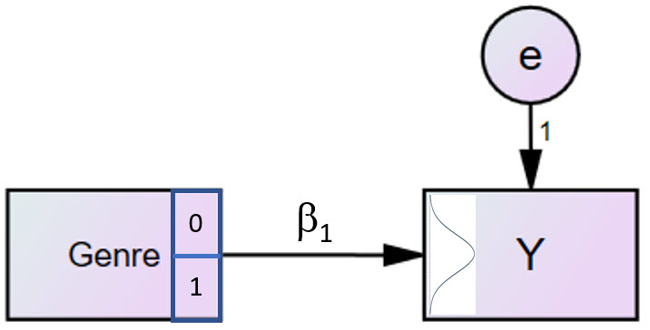

Figure 16.7: Modèle 1, impliquant la variable indépendante Genre, une variable dichotomique. L’objectif est d’examiner son impact sur la variable dépendante y, une variable quantitative.

Les figures suivantes illustrent la présente situation. Des histogrammes produits pour chacun des groupes séparément montre un degré de recouvrement important, mais laisse entrevoir une légère différence quant au centre des distributions. Les diagrammes en boîte qui suivent présentent une image plus claire, semblant indiquer une performance légèrement supérieure chez les femmes (histogramme bleu) que chez les hommes (histogramme rouge).

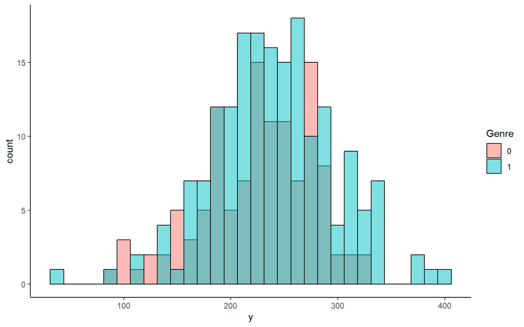

Figure 16.8: Distribution de la performance observée chez les hommes et les femmes. Les zones ombragées sont les portions où il y a recouvrement des deux distributions.

```r
TmpDdat <- data.frame(Genre = factor(Genre), y = y)
ggplot(TmpDdat, aes(x = y, fill = Genre, colour = Genre)) +
  geom_histogram(colour = "black",
                 alpha = 0.5,
                 lwd = 0.5,
                 linetype = 1,
                 position = "identity") +
  theme_classic()
```

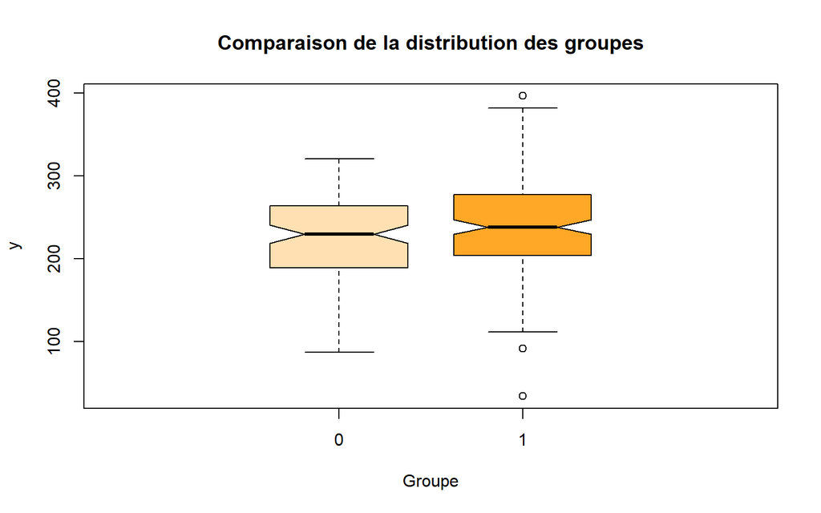

Figure 16.9: Diagrammes en boîte résumant la distribution de la performance observée chez les hommes (Groupe = 0) et les femmes (Groupe = 1).”

```r
boxplot(y ~ Genre,
        main = "Comparaison de la distribution des groupes",
        col = c("#FFE0B2", "#FFA726"),
        xlab = "Groupe",
        range = 1.5,
        notch = TRUE,
        boxwex = 0.3,
        horizontal = FALSE,
        at = c(0, 0.4))
```

Finalement, le diagramme de dispersion affiché à la figure Figure 16.10 suivant présente les observations obtenues des deux groupes, un point rouge indiquant leur moyenne respective. La droite liant ces points réflète le modèle proposé, soit une droite définie par l’équation Équation 16.6:

$$\hat{y} =\beta_0 + \beta_1 Genre + \epsilon \tag{16.6}$$

Les paramètres de ce modèle sont:

1. $\beta_0$, l’intercept, estimé par $b_0$
2. $\beta_1$, la pente ou coefficient de régression, estimé par $b_1$
3. $\sigma_{\epsilon}^2$, la variance des erreurs, estimé par $s_e^2$

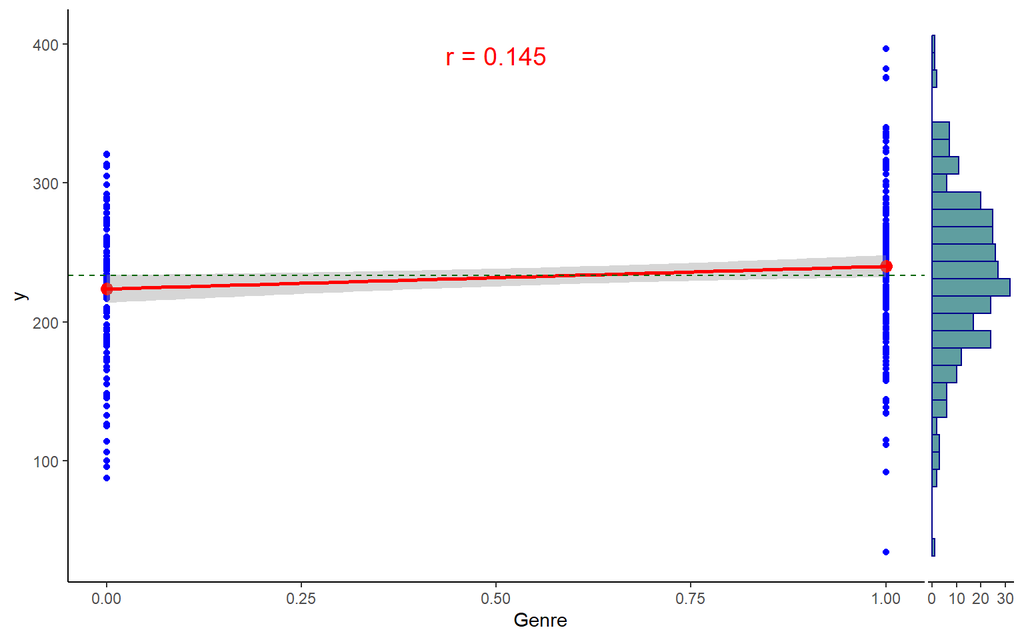

Figure 16.10: Diagramme de dispersion illustrant la relation entre la variable dichotomique Genre et la variable dépendante y. La droite reliant les moyennes des deux groupes (points rouges) possède une pente égale à la différence entre les deux moyennes. La ligne pointillée horizontale verte marque la position de la moyenne de y.

```r
p <- ggplot(dat,
            aes(x=Genre, y=y)) +
  geom_point(color = "blue") +
  geom_point(aes(x=0, y=mean(y[Genre == 0. ])), size = 3, colour="red") +
  geom_point(aes(x=1, y=mean(y[Genre == 1. ])), size = 3, colour="red") +
  theme(legend.position="none") +
  geom_smooth(method = lm,
              color = "red") +
  geom_hline(yintercept = mean(y, ),
             linetype = 'dashed',
             color = 'darkgreen',
             size = 0.5) +
  theme_classic() +
  annotate("text",
           0.5,
           max(y) - 5,
           label = paste0("r = ", round(cor(Genre, y), 3)),
           col = "red",
           size = 5)

p + geom_ysidehistogram(
  mapping = NULL,
  data = dat,
  color = "darkblue",
  fill = "cadetblue",
  stat = "bin",
  position = "stack",
  binwidth = NULL,
  bins = NULL,
  na.rm = FALSE,
  orientation = "y",
  show.legend = NA,
  inherit.aes = TRUE
)
```

Modèle 1: Ajout de Genre

$$\operatorname{y} = {\color{blue}{\beta_{0}}} + {\color{blue}{\beta}}_{{\color{blue}{1}}}(\operatorname{Genre}) + {\color{blue}{\epsilon}}$$

L’analyse de ce modèle produit les résultats suivants:

$$\operatorname{\widehat{y}} = \underset{(5.024)}{223.794} + \underset{(6.468)}{16.307(\operatorname{Genre})}$$

```r
reg1 <- lm(y ~ Genre, data = dat)
res1 <- summary(reg1)
resid1 <- residuals(reg1) # Calcul des erreurs

reg1 %>%
  tbl_regression(intercept = TRUE) %>%
  add_significance_stars(hide_ci = FALSE,
                         hide_p = FALSE) %>%
  bold_p() %>%
  add_glance_table(
    include = c("r.squared", "adj.r.squared",
                "df.residual", "sigma", "nobs"))
```

| **Characteristic** | **Beta**<sup>1</sup> | **SE**<sup>2</sup> | **95% CI**<sup>2</sup> | **p-value** |
| --- | --- | --- | --- | --- |
| (Intercept) | 224*** | 5.02 | 214, 234 | <0.001 |
| Genre | 16* | 6.47 | 3.6, 29 | 0.012 |
| R² | 0.021 |  |  |  |
| Adjusted R² | 0.018 |  |  |  |
| Residual df | 298 |  |  |  |
| Sigma | 54.8 |  |  |  |
| No. Obs. | 300 |  |  |  |

<sup>1</sup> *p<0.05; **p<0.01; ***p<0.001  
<sup>2</sup> SE = Standard Error, CI = Confidence Interval

De ces résultats, on note que l’intercept est égal à 223.794, indiquant la performance moyenne des hommes (Genre = 0). En effet, l’intercept est la moyenne de la variable dépendante lorsque la valeur de la variable indépendante est nulle. Cette moyenne est significativement différente de 0, tel qu’indiqué par le test de signification correspondant à ce paramètre.

D’autre part, le coefficient liant Genre à la performance, $b_{Genre}$ = 16.307, indique que pour une augmentation d’une unité dans la variable Genre, soit le passage de Genre = 0 (homme) à Genre = 1 (femme), la performance moyenne augmente de 16.307 unités. Ce coefficient correspond donc à la différence de la performance moyenne entre les hommes et les femmes, différence qui s’avère statistiquement significative.

Le fait que la variable Genre ait un impact sur la performance implique que la variance des erreurs est inférieure à la variance de la variable dépendante: elle permet d’en expliquer une certaine proportion.

%Variance expliquée = $1-\frac{s_{y.Genre}^2}{s_y^2}=1-\frac{2993.9239}{3057.7737}=$ 0.0209

Il semble donc que le groupe d’appartenance des sujets permet d’expliquer une portion de la variabilité totale. Cette variable représente un facteur susceptible de déterminer la performance.

Ce résultat indique que la variable *Genre* explique 2.09% de la variabilité de $y$. On retrouve cette quantité dans la tableau inférieur des résultats de l’analyse effectuée sur ces données, sous le terme *Multiple R-squared*. Il s’agit du **coefficient de détermination**, ou $R^2$. Cet indice est omniprésent dans le contexte d’analyses quantitatives et fera l’objet d’une discussion ultérieure.

Comparons les deux modèles étudiés jusqu’ici:

```r
models <- list(
  "Constante" = lm(y ~
                     1, data = dat),
  "Constante + Genre" = lm(y ~ Genre, data = dat))
modelsummary(models,
             title = "Paramètres des modèles étudiés",
             statistic = c("std.error"),
             stars = TRUE,
             coef_rename = TRUE)
```

Table 16.2: Paramètres et statistiques pertinentes obtenus pour le modèle nul (Constante) et pour le modèle impliquant la variable Genre.”

Paramètres des modèles étudiés

|  | Constante | Constante + Genre |
| --- | --- | --- |
| (Intercept) | 233.632*** | 223.794*** |
|  | (3.193) | (5.024) |
| Genre |  | 16.307* |
|  |  | (6.468) |
| Num.Obs. | 300 | 300 |
| R2 | 0.000 | 0.021 |
| R2 Adj. | 0.000 | 0.018 |
| AIC | 3262.0 | 3257.7 |
| BIC | 3269.4 | 3268.8 |
| Log.Lik. | −1628.997 | −1625.832 |
| F |  | 6.355 |
| RMSE | 55.20 | 54.63 |

+ p < 0.1, * p < 0.05, ** p < 0.01, *** p < 0.001

Il est important de noter que les résultats obtenus se fondent sur les observations faites auprès d’un échantillon. Un échantillon différent fournirait des résultats plus ou moins différents. Ce fait se démontre aisément à l’aide d’une simulation. En ré-échantillonnant 10,000 fois les observations initiales, on obtient les distributions d’échantillonnage de l’intercept et du coefficient liant *Genre* à $y$:

```r
# Bootstrap 95% IC pour les paramètres de la régression

# Fonction permettant d'obtenir les coefficients
bs <- function(formula, data, indices) {
  d <- data[indices,]
  fit <- lm(formula, data=d)
  return(coef(fit))
}

# Ré-échantillonnage (10000 replications)
results <- boot(data=dat,
                statistic=bs,
                R=10000,
                formula=y ~ Genre)
results
```

```
#>
#> ORDINARY NONPARAMETRIC BOOTSTRAP
#>
#>
#> Call:
#> boot(data = dat, statistic = bs, R = 10000, formula = y ~ Genre)
#>
#>
#> Bootstrap Statistics :
#>      original     bias    std. error
#> t1* 223.79385 0.02185535    4.658899
#> t2*  16.30659 0.01083986    6.358496
```

Dans de tableau, t1* représente l’intercept, et t2* le coefficient liant Genre à $y$. On constate que les paramètres obtenus sont les mêmes que ceux obtenus à l’aide de la fonction **lm()**. Ce résultat est attendu, étant donné que ce sont les mêmes observations qui sont ré-échantillonnées un grand nombre de fois. Les erreurs-standards de ces quantités sont également similaires dans le présent cas, mais pourraient différer en fonction des caractéristiques des données (forme de la distribution, degré d’asymétrie, etc). Les figures Figure 16.11 et Figure 16.12 reproduisent les distributions de ré-échantillonnage correspondantes, ainsi que les diagrammes de probabilités normales, témoignant de la normalité de ces distributions.

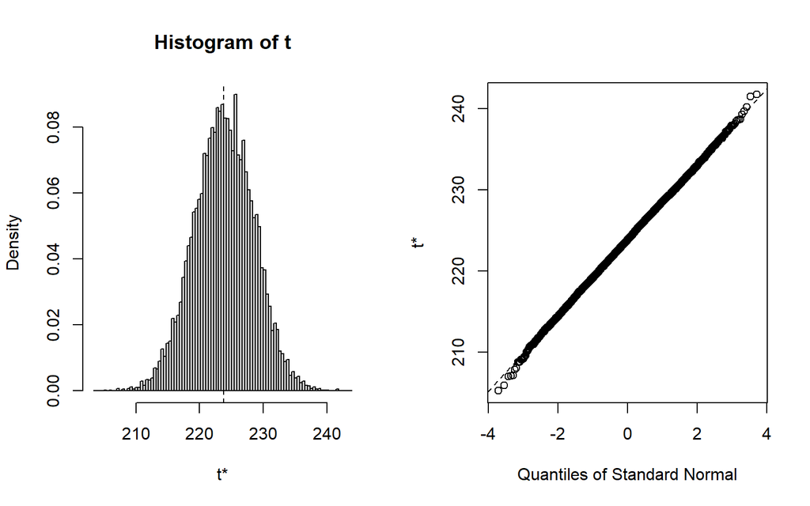

Figure 16.11: Distribution de ré-échantillonnage de l’Intercept, obtenue à partir de 10,000 itérations, , et diagramme de probabilité normale confirmant la normalité de cette distribution.

```r
plot(results, index=1) # intercept
```

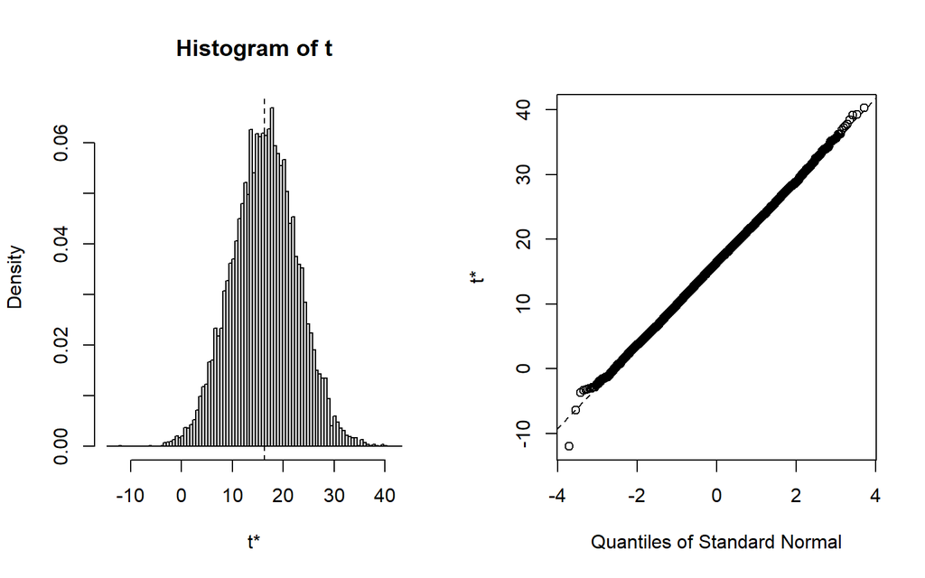

Figure 16.12: Distribution de ré-échantillonnage du coefficient de régression (Genre), obtenue à partir de 10,000 itérations, et diagramme de probabilité normale confirmant la normalité de cette distribution.

```r
plot(results, index=2) # Genre
```

Notons qu’un coefficient de régression nul est peu probable, dans le cas présent. La presque totalité de la distribution s’étend au-delà de 0, ce qui laisse croire qu’il existe réellement un lien entre le sexe des sujets et leur performance.

Finalement, on peut obtenir les intervalles de confiance fondés sur les distributions de ré-échantillonnage afin de déterminer l’étendue de valeurs susceptible de capturer le véritable paramètre au niveau de la population, avec un degré de confiance de 95%:

```r
# Intervalles de confiance (95%)
boot.ci(results, type="bca", index=1) # intercept
```

```
#> BOOTSTRAP CONFIDENCE INTERVAL CALCULATIONS
#> Based on 10000 bootstrap replicates
#>
#> CALL :
#> boot.ci(boot.out = results, type = "bca", index = 1)
#>
#> Intervals :
#> Level       BCa
#> 95%   (214.4, 232.6 )
#> Calculations and Intervals on Original Scale
```

```r
boot.ci(results, type="bca", index=2) # Genre
```

```
#> BOOTSTRAP CONFIDENCE INTERVAL CALCULATIONS
#> Based on 10000 bootstrap replicates
#>
#> CALL :
#> boot.ci(boot.out = results, type = "bca", index = 2)
#>
#> Intervals :
#> Level       BCa
#> 95%   ( 3.82, 28.56 )
#> Calculations and Intervals on Original Scale
```

Ni pour l’intercept, ni pour le coefficient de régression, une valeur nulle n’est incluse dans l’intervalle, confirmant la faible probabilité que l’un ou l’autre des paramètres soit égal à 0.

En conclusion, les résultats des analyses effectuées sur les données nous porte à croire que le sexe des individus a un impact sur la performance (variable $y$), En effet, ce facteur permet de rendre compte de 2.1% de la variabilité de la performance. De plus, puisque la variable indépendante est dichotomique, le coefficient de régression représente la différence entre les moyennes des deux groupes, de sorte que le test de signification appliqué sur ce coefficient est de fait un test de signification de cette différence.

## 16.4 Un prédicteur quantitatif

Tel que mentionné précédemment, une variable indépendante (prédicteur) peut être de nature qualitative ou quantitative. Dans la section précédente, le modèle proposé pour expliquer une portion de la variabilité de la performance incluait une variable dichotomique, qualitative. Dans la présente section, le travail sera répété mais en introduisant la variable **x1**, un prédicteur quantitatif. Dans ce cas, le modèle prend la forme de l’équation Équation 16.6:

$$\hat{y}=\beta_0 + \beta_1 x1 + \epsilon$$

Comme dans le cas précédent, le modèle ne fait appel qu’à une seule variable indépendante et ses paramètres demeurent inchangés:

1. $\beta_0$, l’intercept, estimé par $b_0$
2. $\beta_1$, la pente ou coefficient de régression, estimé par $b_1$
3. $\sigma_{\epsilon}^2$, la variance des erreurs, estimé par $s_e^2$

La figure Figure 16.13 représente ce modèle:

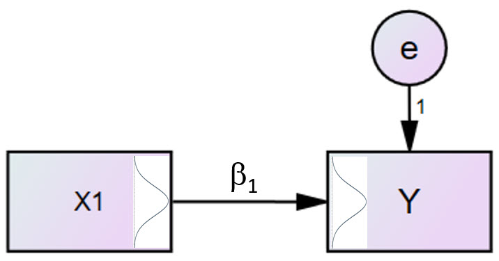

S’il existe une relation entre $y$ et $x1$, on devrait pouvoir observer une réduction de la variance des erreurs en incluant $x1$ dans le modèle, comme ce fut le cas suite à l’introduction de la variable Genre, dans la section précédente. La figure Figure 16.14 illustre cette relation:

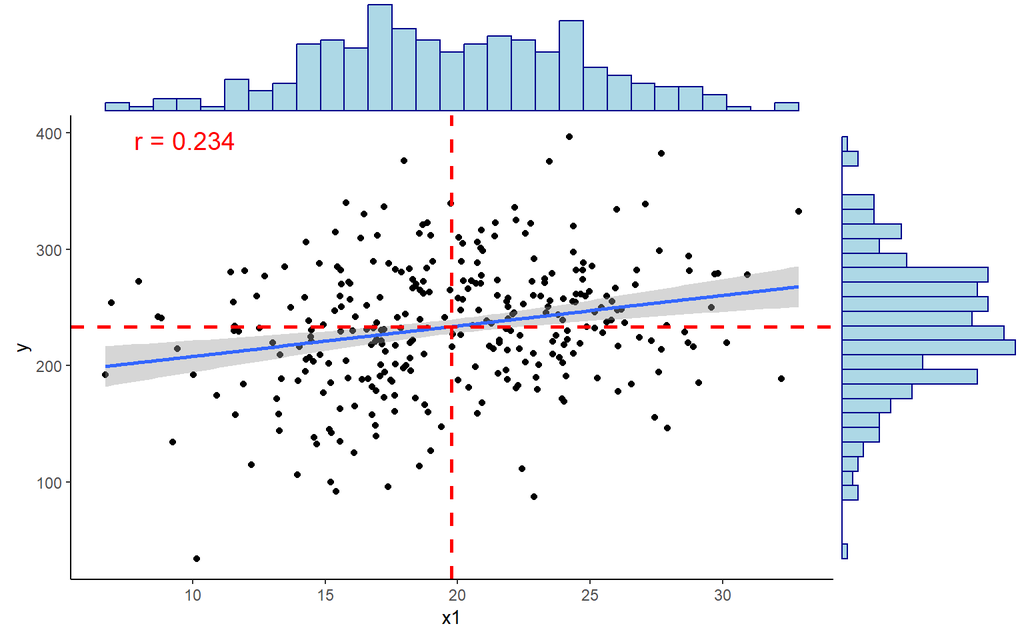

Figure 16.14: Représentation de la relation entre la variable dépendante y et la variable indépendante x1. La ligne pointillée rouge horizontale indique la position de la moyenne de y, alors que la ligne verticale indique la position de la moyenne de x1. Le centre de gravité du nuage de points se trouve à l’intersection de ces deux droites. Les distributions de fréquences des variables sont affichées au-dessus (variable x1) et à droite (variable y) du diagramme de dispersion.

```r
p <- ggplot(dat, aes(x1, y)) +
  geom_point() +
  geom_smooth(method='lm') +
  theme_classic() +
  geom_vline(xintercept = mean(x1, ),
             linetype = 'dashed',
             color = 'red',
             size = 1) +
    geom_hline(yintercept = mean(y, ),
             linetype = 'dashed',
             color = 'red',
             size = 1) +
    annotate("text",
           min(x1) + 3,
           max(y) - 3,
           label = paste0("r = ", round(cor(x1, y), 3)),
           col = "red",
           size = 5)
ggExtra::ggMarginal(p, type = "histogram",
                    size = 4,
                    color="darkblue", fill="lightblue")
```

Ce diagramme indique une relation positive entre les deux variables. Supposant une relation linéaire, le coefficient de corrélation est égal à 0.234. Cette corrélation est une estimation de la corrélation réelle entre $y$ et x1, au niveau de la population. Elle est assujettie aux fluctuations d’échantillonnage. Cependant, on peut obtenir sa distribution d’échantillonnage à l’aide d’une procédure de ré-échantillonnage, donnant les résultats suivants, suite à 100,000 réplications:

```r
b3 <- boot(dat,
           statistic = function(data, i) {
             cor(data[i, "x1"], data[i, "y"], method='pearson')
             },
           R = 100000
           )
b3
```

```
#>
#> ORDINARY NONPARAMETRIC BOOTSTRAP
#>
#>
#> Call:
#> boot(data = dat, statistic = function(data, i) {
#>     cor(data[i, "x1"], data[i, "y"], method = "pearson")
#> }, R = 1e+05)
#>
#>
#> Bootstrap Statistics :
#>      original        bias    std. error
#> t1* 0.2335409 -0.0004882288  0.05265621
```

Sans surprise, la moyenne de la distribution d’échantillonnage, $\mu_r$, est égale à 0.234. Elle correspond à la corrélation observée entre $y$ et x1, pour l’échantillon étudié. L’erreur-standard de cette distribution est égale à $\sigma_{r}=$ 0.053. Puisque $r=0$ se trouve à plus de $\frac{ 0.234 }{ 0.053} = 4.435\sigma_r$ de la valeur estimée, une hypothèse proposant une corrélation nulle entre $x1$ et y, au niveau de la population, ne semble pas appuyée par les données analysées, étant hautement improbable. Les figures Figure 16.15 et Figure 16.16 en sont des illustrations:

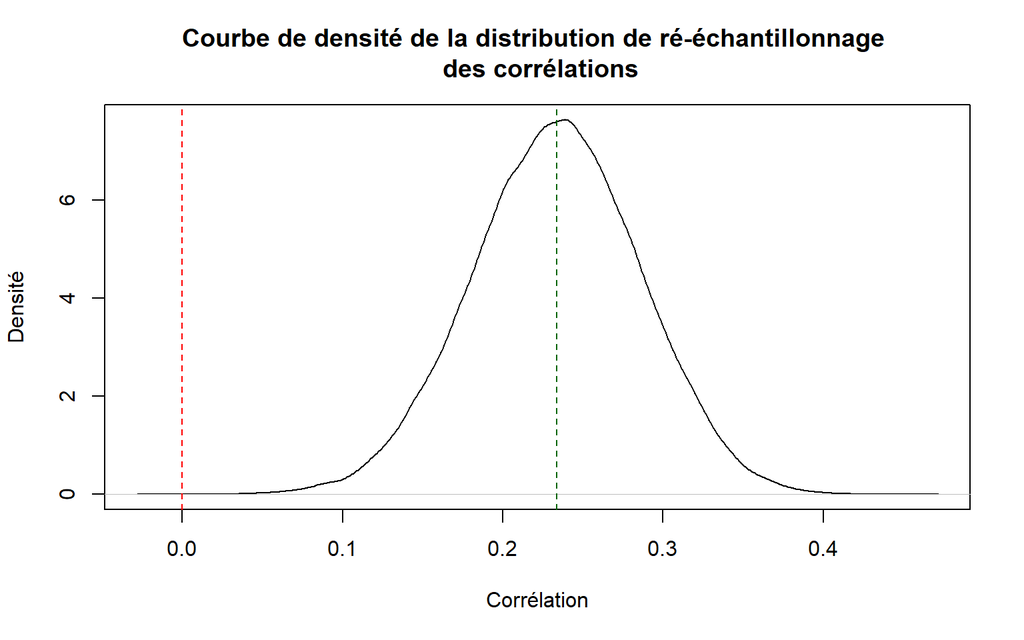

Figure 16.15: Courbe de densité de la distribution de ré-échantillonnage des corrélations. La ligne verticale rouge indique r = 0, la valeur proposée dans un test d’hypothèse. Se trouvant très loin dans l’extrémité inférieure, cette valeur est hautement improbable.

```r
plot(density(b3$t),
     main = "Courbe de densité de la distribution de ré-échantillonnage \n des corrélations",
     ylab = "Densité",
     xlab = "Corrélation")
abline(v = 0,
       lty = "dashed",
       col = "red")
abline(v = cor(x1, y),
       lty = "dashed",
       col = "darkgreen")
```

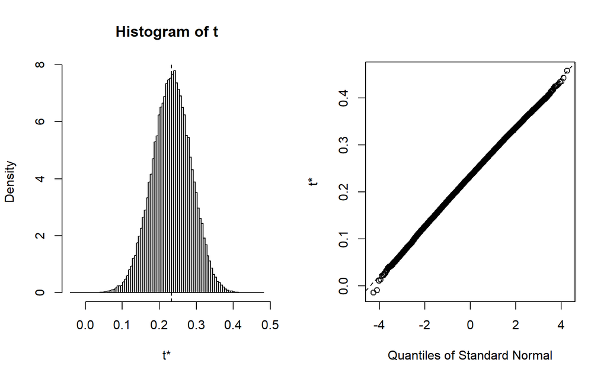

```r
plot(b3, index=1)
```

### 16.4.1 Note concernant la variance des erreurs

La figure Figure 16.3 a permis une visualisation de la contribution d’une donnée à la variance d’un ensemble de score, contribution qui est une fonction de la distance qui la sépare de la moyenne de cet ensemble. Dans le contexte d’une relation linéaire entre deux variables, on peut produire une visualisation similaire lorsque deux variables sont impliquées. Dans ce cas, une erreur se défini par l’équation Équation 16.7:

$$e_i= y_i-\hat{y} \tag{16.7}$$

où $\hat{y}$ est la valeur prédite de $y$ en tenant compte de la variable indépendante. La détermination des paramètres d’un modèle de régression implique un processus visant à minimiser la somme des $e_i^2$. Dans ce cas, la variance des erreurs se définit par l’équation Équation 16.8 :

$$s_e^2=\frac{\sum\limits_{i=1}^ne_i^2}{n-1}=\frac{\sum\limits_{i=1}^n(y_i-\hat{y})^2}{n-1} \tag{16.8}$$

La figure Figure 16.17 illustre la nature de la contribution de chaque observation à cette variance:

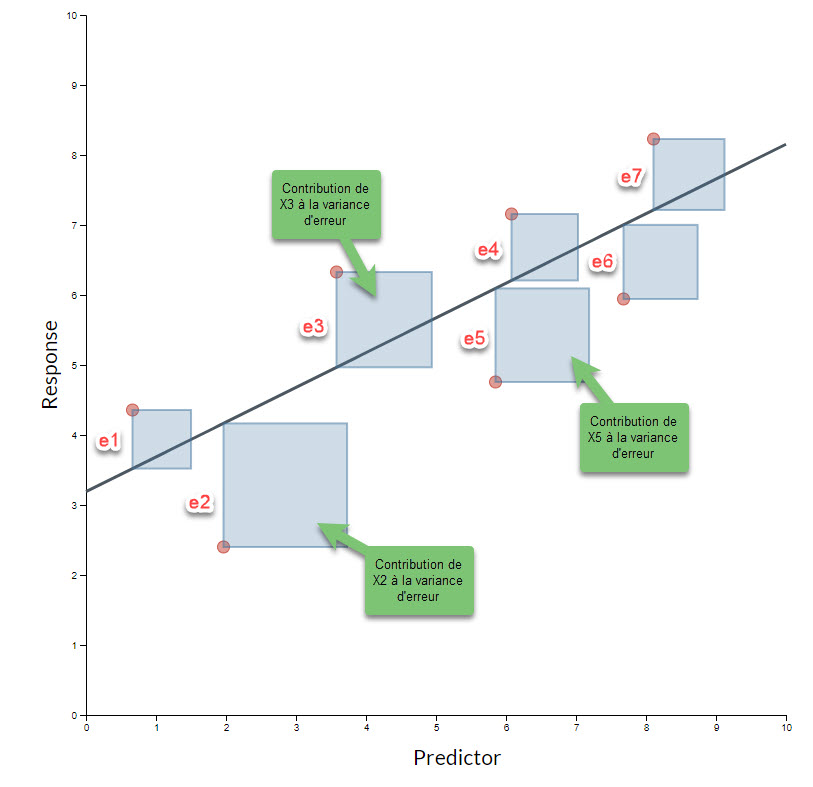

Figure 16.17: Contribution d’une observation à la variance des erreurs

Dans cette figure, les erreurs sont les distances verticales entre les points et la droite de régression. La mise au carré de ces erreurs équivaut à la formation de carrés, dont la surface représente la contribution d’une observation à la variance, qui n’est que la somme des surfaces, divisée par le nombre de points moins 1. Plus un point est éloigné de la droite, plus sa contribution est importante.

### 16.4.2 Estimation des paramètres

Démonstration faite qu’une relation pourrait exister entre les variables $x1$ et $y$, il convient d’examiner dans quelle mesure $x1$ pourrait permettre d’expliquer une portion de la variabilité de $y$.

Modèle 2: Ajout de x1

$$\operatorname{y} = {\color{blue}{\beta_{0}}} + {\color{blue}{\beta}}_{{\color{blue}{1}}}(\operatorname{x1}) + {\color{blue}{\epsilon}}$$

Un examen détaillé de ces données à l’aide de la fonction **lm()** fournit les résultats suivants:

$$\operatorname{\widehat{y}} = \underset{(12.865)}{181.874} + \underset{(0.632)}{2.619(\operatorname{x1})}$$

```r
reg2 <- lm(y ~ x1, data = dat)
res2 <- summary(reg2)
resid2 <- residuals(reg2) # Calcul des valeurs résiduelles

res2 %>%
  tbl_regression(intercept = TRUE) %>%
  add_significance_stars(hide_ci = FALSE,
                         hide_p = FALSE) %>%
  bold_p() %>%
  add_glance_table(
    include = c("r.squared", "adj.r.squared", "df.residual", "sigma", "nobs"))
```

| **Characteristic** | **Beta**<sup>1</sup> | **SE**<sup>2</sup> | **95% CI**<sup>2</sup> | **p-value** |
| --- | --- | --- | --- | --- |
| (Intercept) | 182*** | 12.9 | 157, 207 | <0.001 |
| x1 | 2.6*** | 0.632 | 1.4, 3.9 | <0.001 |
| R² | 0.055 |  |  |  |
| Adjusted R² | 0.051 |  |  |  |
| Residual df | 298 |  |  |  |
| Sigma | 53.9 |  |  |  |
| No. Obs. | 300 |  |  |  |

<sup>1</sup> *p<0.05; **p<0.01; ***p<0.001  
<sup>2</sup> SE = Standard Error, CI = Confidence Interval

Le coefficient de régression liant $x1$ à $y$ est égal à $b_{x1}=2.619$, une valeur jugée statistiquement significative ($t_{298}=4.146$, $p<0.001$). Ce coefficient implique qu’une augmentation d’une unité de la variable $x$ se traduirait par une augmentation de 2.619 unité dans la variable $y$. Pour sa part, l’intercept, $b_0=$ 181.874, correspond à la performance moyenne ($y$) chez un individu pour qui $x1=0$. Notons que cette interprétation de l’intercept n’est valide que si:

1. $x1=0$ est une valeur possible pour cette variable. Dans le cas présent, cette condition pourrait ne pas être respectée. En effet, la valeur minimale de $x1$ est 6.702, et il est possible que $x1=0$ n’existe pas.
2. Les données incluent des observations autour de cette valeur.

Si ces conditions ne sont pas respectées, on ne peut fournir une interprétation de l’intercept. Il s’agit simplement d’une valeur nécessaire pour obtenir des prédictions valides.

Une stratégie souvent utilisée pour s’assurer de l’interprétabilité de l’intercept est de transformer la variable indépendante en la centrant sur sa moyenne. La transformation requise dans ce cas est définie par l’équation Équation 16.9:

$$xc_i=x_i-\overline{x} \tag{16.9}$$

La moyenne d’un ensemble de déviation par rapport à la moyenne étant nécessairement 0, l’interprétation de l’intercept devient alors la moyenne conditionnelle de la variable dépendante lorsque $x=\overline{x}$. Pour fin d’exemple, on applique cette opération sur $x1$ et on relance l’analyse:

```r
xc <- x1 - mean(x1)
reg2b <- lm(y ~ xc)
res2b <- summary(reg2b)

reg2b %>%
  tbl_regression(intercept = TRUE) %>%
  add_significance_stars(hide_ci = FALSE,
                         hide_p = FALSE) %>%
  bold_p() %>%
  add_glance_table(
    include = c("r.squared", "adj.r.squared", "df.residual", "sigma", "nobs"))
```

| **Characteristic** | **Beta**<sup>1</sup> | **SE**<sup>2</sup> | **95% CI**<sup>2</sup> | **p-value** |
| --- | --- | --- | --- | --- |
| (Intercept) | 234*** | 3.11 | 228, 240 | <0.001 |
| xc | 2.6*** | 0.632 | 1.4, 3.9 | <0.001 |
| R² | 0.055 |  |  |  |
| Adjusted R² | 0.051 |  |  |  |
| Residual df | 298 |  |  |  |
| Sigma | 53.9 |  |  |  |
| No. Obs. | 300 |  |  |  |

<sup>1</sup> *p<0.05; **p<0.01; ***p<0.001  
<sup>2</sup> SE = Standard Error, CI = Confidence Interval

On note immédiatement que le coefficient de régression demeure inchangé, et son interprétation demeure la même. Par contre, la valeur de l’intercept a changé, passant de 181.874 à 233.632 après l’application de la transformation. Dans ce cas on pourra affirmer que la valeur moyenne de $y$, pour un individu obtenant la valeur moyenne sur $x1$ est égale à 233.632.

Que l’on utilise une variable centrée ou non, la variable $x1$ permet donc d’expliquer une certaine proportion de la variance de $y$, tel que quantifié par le coefficient de détermination, $r^2=$ 0.055. Ce résultat indique que 5.454% de la variance de $y$ peut s’expliquer par la variable indépendante $x1$.

La distribution des valeurs résiduelles obtenues dans ce cas ne semble pas dévier de la normalité de manière importante, tel que suggéré par la figure Figure 16.18:

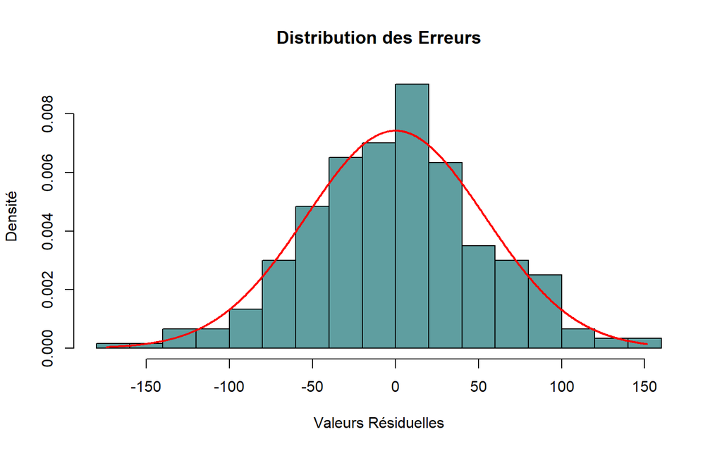

Figure 16.18: Distribution des valeurs résiduelles suite à l’ajout de x1 au modèle.

```r
Ve <- round(var(resid2), 3)
txt1 <- paste("Var(e) = ", Ve)
rcompanion::plotNormalHistogram(
  resid2,
  prob = TRUE,
  col = "cadetblue",
  linecol = "red",
  lwd = 2,
  length = 1000,
  breaks = "FD",
  main = "Distribution des Erreurs",
  xlab = "Valeurs Résiduelles",
  ylab = "Densité")
text(-3, 0.3, labels =txt1)
```

### 16.4.3 Comparaison des modèles

Le tableau Table 16.3 résume les résultats obtenus pour les trois modèles proposés jusqu’à maintenant:

```r
models <- list(
  "Constante" = lm(y ~
                     1, data = dat),
  "Constante + Genre" = lm(y ~ Genre, data = dat),
  "Constante + x1" = lm(y ~ x1, data = dat))
modelsummary(models,
             title = "Paramètres des modèles étudiés",
             statistic = c("std.error"),
             stars = TRUE,
             coef_rename = TRUE)
```

Table 16.3: Paramètres et statistiques pertinentes obtenus pour les 3 modèles étudiés

Paramètres des modèles étudiés

|  | Constante | Constante + Genre | Constante + x1 |
| --- | --- | --- | --- |
| (Intercept) | 233.632*** | 223.794*** | 181.874*** |
|  | (3.193) | (5.024) | (12.865) |
| Genre |  | 16.307* |  |
|  |  | (6.468) |  |
| x1 |  |  | 2.619*** |
|  |  |  | (0.632) |
| Num.Obs. | 300 | 300 | 300 |
| R2 | 0.000 | 0.021 | 0.055 |
| R2 Adj. | 0.000 | 0.018 | 0.051 |
| AIC | 3262.0 | 3257.7 | 3247.2 |
| BIC | 3269.4 | 3268.8 | 3258.3 |
| Log.Lik. | −1628.997 | −1625.832 | −1620.584 |
| F |  | 6.355 | 17.191 |
| RMSE | 55.20 | 54.63 | 53.68 |

+ p < 0.1, * p < 0.05, ** p < 0.01, *** p < 0.001

Une part importante d’une analyse quantitative consiste à comparer différents modèles dans le but de mettre en évidence celui qui s’ajuste le mieux aux données, qui possède le meilleur potentiel de prédiction, tout en demeurant le plus parcimonieux possible. Une foule d’indices numériques peuvent entrer en jeu à ce stade. Certains sont présentés dans la portion inférieure de ce tableau, et d’autres suivront dans les sections ultérieures.

Notons que la comparaison directe des modèles résumés dans ce tableau n’est pas réellement appropriée du fait que les deux variables indépendantes sont examinées séparément. On ne tient pas compte des liens qu’elles pourraient entretenir. Ces comparaisons n’ont été faites que dans le but de présenter les indices numériques appropriés pour l’examen de la qualité d’ajustement d’un modèle.

### 16.4.4 Variabilité des estimations

Comme toute statistique obtenue d’un échantillon, qu’il s’agisse de la moyenne, d’un écart-type, ou de toute autre mesure descriptive, les paramètres d’une régression ($b_0$, $b_1$ et $s_{erreur}^2$) varient d’un échantillon à l’autre. La figure Figure 16.19 illustre ce fait:

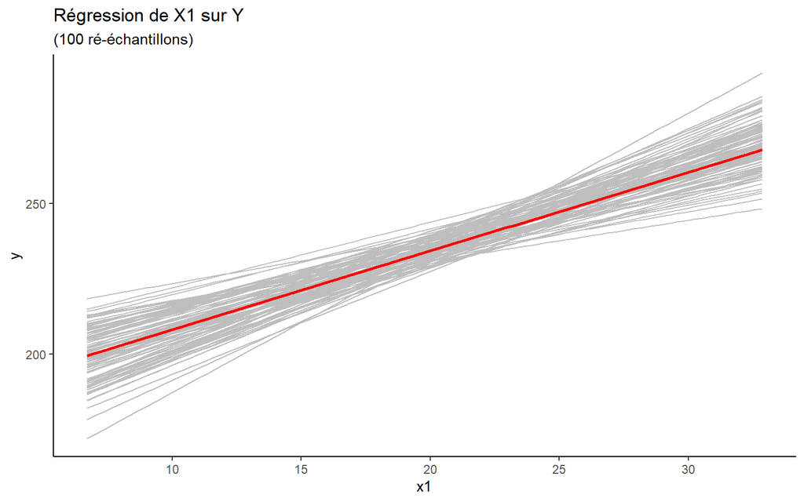

Figure 16.19: Droites de régression obtenues en ré-échantillonnant 100 fois l’échantillon initial. La droite de régression calculée sur les données originales est affichée en rouge.

```r
 rsamp <- dat[, 1:2] %>%
  infer::rep_sample_n(size = n, replace = TRUE, reps = 100)

ggplot() +
  geom_smooth(
    data = rsamp, aes(x = x1, y = y, group = replicate),
    method = "lm", se = FALSE, fullrange = TRUE,
    color = "grey", size = 0.5
  ) +
  geom_smooth(
    data = dat[ , 1:2], aes(x = x1, y = y), method = "lm", se = FALSE,
    fullrange = TRUE, color = "red"
  ) +
  theme_classic() +
  labs(
    title = "Régression de X1 sur Y",
    subtitle = "(100 ré-échantillons)"
  )
```

Il conviendra donc de quantifier cette variation de manière à permettre un examen plus approfondi de la relation entre les variables.

### 16.4.5 Visualisation de l’ajustement d’un modèle de régression

Le terme **ajustement** d’un modèle par rapport aux données réfère à la différence qui pourrait exister entre la distribution des valeurs prédites et celle des valeurs observées de la variable dépendante. Plusieurs indices permettent de quantifier cette différence, mais il est instructif d’en obtenir une visualisation. Le code R produit une simulation dans laquelle la qualité de l’ajustement du modèle aux données est représenté par deux courbes de densité représentant respectivement la distribution de $Y'$ et de $Y$. Dans le premier cas, l’ajustement est mauvais, et dans le second, il est bon:

```r
xt <- rnorm(500)
yt <- 10 + 2 * xt + rnorm(500)/0.25

model <- lm(yt ~ xt)
summary(model)
```

```
#>
#> Call:
#> lm(formula = yt ~ xt)
#>
#> Residuals:
#>      Min       1Q   Median       3Q      Max
#> -12.3946  -2.5609   0.0499   2.6120  11.5788
#>
#> Coefficients:
#>             Estimate Std. Error t value Pr(>|t|)
#> (Intercept)  10.1847     0.1827   55.76   <2e-16 ***
#> xt            1.9804     0.1798   11.02   <2e-16 ***
#> ---
#> Signif. codes:  0 '***' 0.001 '**' 0.01 '*' 0.05 '.' 0.1 ' ' 1
#>
#> Residual standard error: 4.083 on 498 degrees of freedom
#> Multiple R-squared:  0.1959, Adjusted R-squared:  0.1943
#> F-statistic: 121.3 on 1 and 498 DF,  p-value: < 2.2e-16
```

```r
anova(model)
```

```
#> Analysis of Variance Table
#>
#> Response: yt
#>            Df Sum Sq Mean Sq F value    Pr(>F)
#> xt          1 2022.6 2022.56  121.33 < 2.2e-16 ***
#> Residuals 498 8302.0   16.67
#> ---
#> Signif. codes:  0 '***' 0.001 '**' 0.01 '*' 0.05 '.' 0.1 ' ' 1
```

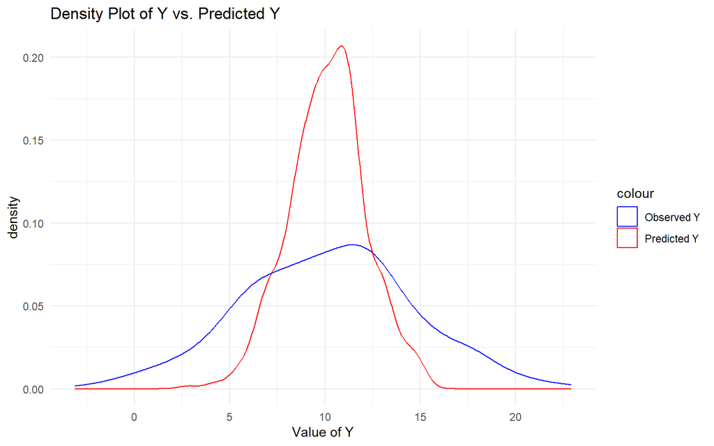

```r
data_df <- data.frame(
  Y = yt,
  Predicted_Y = predict(model)
)

# Create a density plot with two lines
ggplot() +
  geom_density(data = data_df, aes(x = Y, color = "Observed Y"), alpha = 0.5) +
  geom_density(data = data_df, aes(x = Predicted_Y, color = "Predicted Y"), alpha = 0.5) +
  labs(title = "Density Plot of Y vs. Predicted Y", x = "Value of Y") +
  scale_color_manual(values = c("Observed Y" = "blue", "Predicted Y" = "red")) +
  theme_minimal()
```

On note une grande différence entre les deux distributions: l’ajustement est relativement mauvais. Le carré moyen apparaissant dans le tableau de l’analyse de la variance est élevé. Notons que le coefficient de régression est significativement différent de 0, malgré une faible qualité d’ajustement.

Considérons maintenant un bon ajustement:

```r
xt <- rnorm(500)
yt <- 10 + 2 * xt + rnorm(500)

model <- lm(yt ~ xt)
summary(model)
```

```
#>
#> Call:
#> lm(formula = yt ~ xt)
#>
#> Residuals:
#>      Min       1Q   Median       3Q      Max
#> -2.18692 -0.69451 -0.01368  0.65232  3.00421
#>
#> Coefficients:
#>             Estimate Std. Error t value Pr(>|t|)
#> (Intercept)  9.97013    0.04342  229.63   <2e-16 ***
#> xt           2.03625    0.04302   47.34   <2e-16 ***
#> ---
#> Signif. codes:  0 '***' 0.001 '**' 0.01 '*' 0.05 '.' 0.1 ' ' 1
#>
#> Residual standard error: 0.9697 on 498 degrees of freedom
#> Multiple R-squared:  0.8182, Adjusted R-squared:  0.8178
#> F-statistic:  2241 on 1 and 498 DF,  p-value: < 2.2e-16
```

```r
anova(model)
```

```
#> Analysis of Variance Table
#>
#> Response: yt
#>            Df  Sum Sq Mean Sq F value    Pr(>F)
#> xt          1 2106.82 2106.82  2240.6 < 2.2e-16 ***
#> Residuals 498  468.26    0.94
#> ---
#> Signif. codes:  0 '***' 0.001 '**' 0.01 '*' 0.05 '.' 0.1 ' ' 1
```

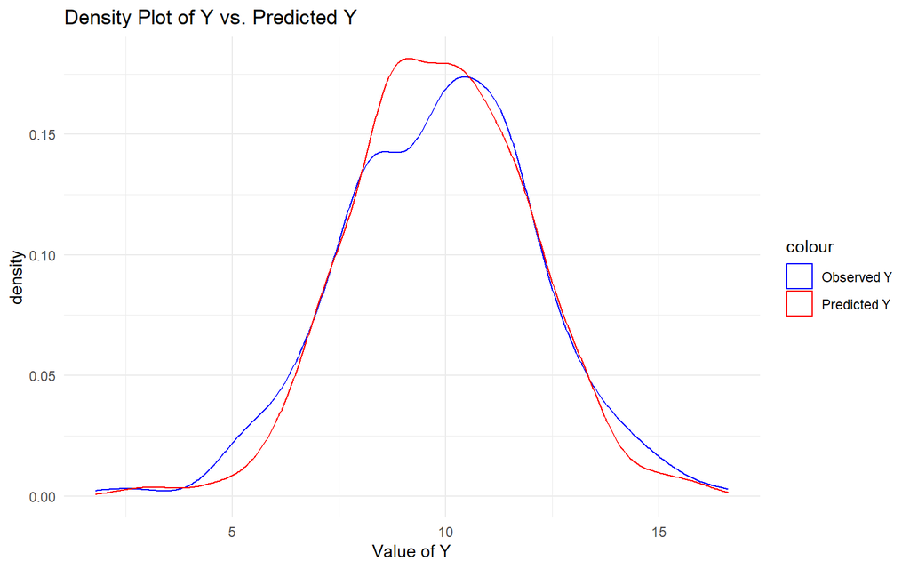

```r
data_df <- data.frame(
  Y = yt,
  Predicted_Y = predict(model)
)

# Create a density plot with two lines
ggplot() +
  geom_density(data = data_df, aes(x = Y, color = "Observed Y"), alpha = 0.5) +
  geom_density(data = data_df, aes(x = Predicted_Y, color = "Predicted Y"), alpha = 0.5) +
  labs(title = "Density Plot of Y vs. Predicted Y", x = "Value of Y") +
  scale_color_manual(values = c("Observed Y" = "blue", "Predicted Y" = "red")) +
  theme_minimal()
```

Ici, les deux courbes sont très similaires: l’ajustement du modèle aux données est très bon, ce que confirme la faible valeur du carré moyen résiduel, affiché dans le tableau de l’analyse de la variance.

## 16.5 Deux prédicteurs: Genre et x1

Dans les sections précédentes, deux variables indépendantes ont été introduites dans des modèles distincts. Chacune d’elles semblent avoir un impact positif sur la variable dépendante (performance). Cependant, il est possible que les deux variables soient corrélées. Or, des analyses séparées ne tiennent pas compte de cette relation: un modèle impliquant ces variables devient essentielle dans ce contexte.

Dans les analyses impliquant séparément $Genre$ et $x1$, la corrélation entre $x1$ et $Genre$, égale à $r_{x1, Genre}=$ -0.072, n’a pas été prise en compte. Certes cette corrélation n’est pas statistiquement différente de 0, mais quel est son impact sur les résultats d’une analyse de régression? Pour répondre à cette question, il suffira de développer un modèle de régression multiple, impliquant ces deux variables.

Le modèle proposé prend la forme générale de l’équation Équation 16.10 :

$$y_i = \mu_y + Genre_i + x1_i + \epsilon_i \tag{16.10}$$

Il propose que la performance d’un individu réflète la performance moyenne au niveau de la population, à laquelle s’ajoute les impacts du Genre et de $x1$, plus une erreur aléatoire. Formellement, le modèle est défini par l’équation Équation 16.11:

$$\hat{y}=\beta_0 + \beta_1 Genre + \beta_2 x_1 + \epsilon \tag{16.11}$$

Les paramètres de ce modèle sont:

1. $\beta_0$, l’intercept, estimé par $b_0$
2. $\beta_1$, la pente ou coefficient de régression associé à la variable Genre, estimé par $b_1$
3. $\beta_2$, la pente ou coefficient de régression associé à la variable x1, estimé par $b_2$
4. $\sigma_{\epsilon}^2$, la variance des erreurs, estimé par $s_e^2$

La figure Figure 16.20 représente ce modèle:

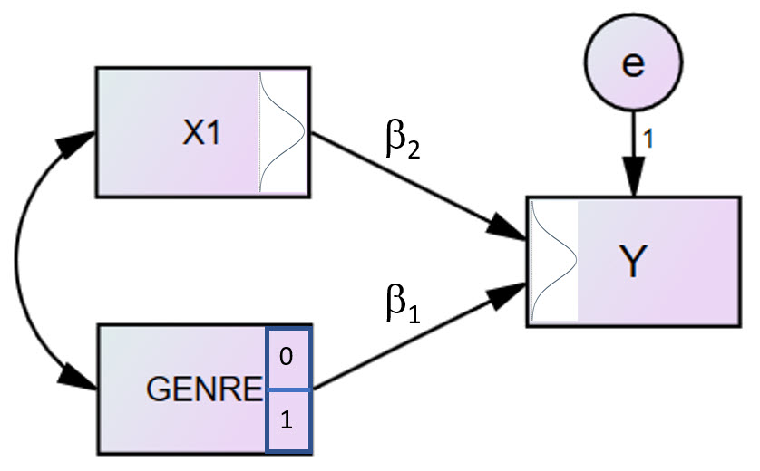

Modèle 3: Ajout de Genre et de x1

$$\operatorname{y} = {\color{blue}{\beta_{0}}} + {\color{blue}{\beta}}_{{\color{blue}{1}}}(\operatorname{Genre}) + {\color{blue}{\beta}}_{{\color{blue}{2}}}(\operatorname{x1}) + {\color{blue}{\epsilon}}$$

L’analyse de ce modèle fournit les résultats suivants:

$$\operatorname{\widehat{y}} = \underset{(13.715)}{165.668} + \underset{(6.307)}{19.575(\operatorname{Genre})} + \underset{(0.627)}{2.842(\operatorname{x1})}$$

```r
reg3 <- lm(y ~ Genre + x1, data = dat)
res3 <- summary(reg3)

reg3 %>%
  tbl_regression(intercept = TRUE) %>%
  add_significance_stars(hide_ci = FALSE,
                         hide_p = FALSE) %>%
  bold_p() %>%
  add_glance_table(
    include = c("r.squared", "adj.r.squared", "df.residual",
               "sigma", "AIC", "BIC", "nobs"))
```

| **Characteristic** | **Beta**<sup>1</sup> | **SE**<sup>2</sup> | **95% CI**<sup>2</sup> | **p-value** |
| --- | --- | --- | --- | --- |
| (Intercept) | 166*** | 13.7 | 139, 193 | <0.001 |
| Genre | 20** | 6.31 | 7.2, 32 | 0.002 |
| x1 | 2.8*** | 0.627 | 1.6, 4.1 | <0.001 |
| R² | 0.084 |  |  |  |
| Adjusted R² | 0.078 |  |  |  |
| Residual df | 297 |  |  |  |
| Sigma | 53.1 |  |  |  |
| AIC | 3,240 |  |  |  |
| BIC | 3,254 |  |  |  |
| No. Obs. | 300 |  |  |  |

<sup>1</sup> *p<0.05; **p<0.01; ***p<0.001  
<sup>2</sup> SE = Standard Error, CI = Confidence Interval

Ces résultats indiquent que:

1. La performance moyenne chez les hommes (Genre = 0) dont le score sur la variable x1 est nul est égale à $b_0 = 165.668$
2. La différence entre les performances moyennes des hommes et des femmes est égale à $b_{Genre} = 19.575$, contrôlant ou maintenant constante la variable x1. La différence observée est jugée statistiquement significative ($t_{ 297 } = 3.103$), $p<0.05$).
3. Maintenant la variable Genre constante, ou contrôlant cette variable, une augmentation d’une unité dans la variable x1 se traduirait en moyenne par une augmentation de $b_{x1} = 2.842$ unité dans la variable dépendante $y$, un impact statistiquement significative ($t_{ 297 } = 4.533$), $p<0.01$).
4. La combinaison linéaire des deux variables indépendantes (Genre et x1) permet d’expliquer $R^2= 8.4$% de la variance de $y$. On note que cette proportion est très rapprochée de la somme des proportions obtenues pour chacune des variables individuelles.

On note que les coefficients obtenus de cette analyse sont similaires à ceux obtenus des analyses de modèles n’impliquant que l’une des variables indépendantes à la fois. Cette observation nous permet de croire que dans un contexte de régression multiple: **la contribution de variables indépendantes individuelles sont additives, si ces variables sont orthogonales (non corrélées)**. Dans le cas présent, la corrélation entre Genre et x1 est faible ($r_{x1, Genre}=-0.072$), ce qui permet l’application de cette interprétation.

### 16.5.1 Comparaison des modèles

Le tableau Table 16.4 résume les résultats obtenus pour les trois modèles proposés jusqu’à maintenant:

```r
models <- list(
  "Constante + Genre" = lm(y ~ Genre, data = dat),
  "Constante + x1" = lm(y ~ x1, data = dat),
  "Constante + x1 + Genre" = lm(y ~ x1 + Genre, data = dat))
modelsummary(models,
             title = "Paramètres des modèles étudiés",
             statistic = NULL,
             coef_rename = TRUE)
```

Table 16.4: Paramètres et statistiques pertinentes obtenus pour les 3 modèles étudiés

Paramètres des modèles étudiés

|  | Constante + Genre | Constante + x1 | Constante + x1 + Genre |
| --- | --- | --- | --- |
| (Intercept) | 223.794 | 181.874 | 165.668 |
| Genre | 16.307 |  | 19.575 |
| x1 |  | 2.619 | 2.842 |
| Num.Obs. | 300 | 300 | 300 |
| R2 | 0.021 | 0.055 | 0.084 |
| R2 Adj. | 0.018 | 0.051 | 0.078 |
| AIC | 3257.7 | 3247.2 | 3239.6 |
| BIC | 3268.8 | 3258.3 | 3254.4 |
| Log.Lik. | −1625.832 | −1620.584 | −1615.797 |
| F | 6.355 | 17.191 | 13.660 |
| RMSE | 54.63 | 53.68 | 52.83 |

On note que l’ajout de la variable x1 au modèle comprenant déjà la variable Genre, ou de la variable Genre au modèle comprenant déjà la variable x1, ne se traduit pas par un changement important dans la valeur des coefficients de régression. Cette ‘invariance’ est due à la relative orthogonalité des variables indépendantes. De ce fait, la contribution de chaque variable à l’explication de la variance de $y$ s’additionne lorsqu’on les introduit simultanément dans un modèle.

Les indices de qualité de l’ajustement (AIC, BIC, Log.Lik. et RMSE) indiquent que le modèle impliquant à la fois Genre et x1 est le plus performant, et correspond à celui qui devrait être retenu.

.

## 16.6 Trois prédicteurs: Genre, x1 et x4

La matrice des corrélations affichées à la figure Figure 16.1 indique une relation significative entre $y$ et $x4$ ($r_{y, x4}=0.367$) laisse présager une contribution significative à la régression: x4 pourrait expliquer une portion additionnelle de la variance de $y$. Le modèle dès lors proposé prend la forme de l’équation Équation 16.12:

$$\hat{y}=\beta_0 + \beta_1 x_1 + \beta_2 x4 + \beta_3 Genre + \epsilon \tag{16.12}$$

Les paramètres de ce modèle sont:

1. $\beta_0$, l’intercept, estimé par $b_0$
2. $\beta_1$, la pente ou coefficient de régression associé à la variable x1, estimé par $b_1$
3. $\beta_2$, la pente ou coefficient de régression associé à la variable x4, estimé par $b_2$
4. $\beta_3$, la pente ou coefficient de régression associé à la variable Genre, estimé par $b_3$
5. $\sigma_{\epsilon}^2$, la variance des erreurs, estimé par $s_e^2$

La figure Figure 16.21 représente ce modèle:

[figure not shown]

Modèle 4: Ajout de x1, x4 et Genre

$$\operatorname{y} = {\color{blue}{\beta_{0}}} + {\color{blue}{\beta}}_{{\color{blue}{1}}}(\operatorname{Genre}) + {\color{blue}{\beta}}_{{\color{blue}{2}}}(\operatorname{x1}) + {\color{blue}{\beta}}_{{\color{blue}{3}}}(\operatorname{x4}) + {\color{blue}{\epsilon}}$$

L’analyse de ce modèle fournit les résultats suivants:

$$\operatorname{\widehat{y}} = \underset{(17.718)}{75.133} + \underset{(5.817)}{18.957(\operatorname{Genre})} + \underset{(0.578)}{2.992(\operatorname{x1})} + \underset{(0.595)}{4.339(\operatorname{x4})}$$

```r
reg4 = lm(y ~ x1 + x4 + Genre, data = dat)
res4 = summary(reg4)

reg4 %>%
  tbl_regression(intercept = TRUE) %>%
  add_significance_stars(hide_ci = FALSE,
                         hide_p = FALSE) %>%
  bold_p() %>%
  add_glance_table(
    include = c("r.squared", "adj.r.squared", "df.residual",
                "sigma", "AIC", "BIC", "nobs"))
```

| **Characteristic** | **Beta**<sup>1</sup> | **SE**<sup>2</sup> | **95% CI**<sup>2</sup> | **p-value** |
| --- | --- | --- | --- | --- |
| (Intercept) | 75*** | 17.7 | 40, 110 | <0.001 |
| x1 | 3.0*** | 0.578 | 1.9, 4.1 | <0.001 |
| x4 | 4.3*** | 0.595 | 3.2, 5.5 | <0.001 |
| Genre | 19** | 5.82 | 7.5, 30 | 0.001 |
| R² | 0.224 |  |  |  |
| Adjusted R² | 0.216 |  |  |  |
| Residual df | 296 |  |  |  |
| Sigma | 49.0 |  |  |  |
| AIC | 3,192 |  |  |  |
| BIC | 3,210 |  |  |  |
| No. Obs. | 300 |  |  |  |

<sup>1</sup> *p<0.05; **p<0.01; ***p<0.001  
<sup>2</sup> SE = Standard Error, CI = Confidence Interval

Ces résultats indiquent que:

1. La performance moyenne chez les hommes (Genre = 0) dont les scores sur les variables x1 et x4 sont nuls est égale à $b_0 = 75.133$
2. La différence entre les performances moyennes des hommes et des femmes est égale à $b_{Genre} = 18.957$, contrôlant ou maintenant constante les variables x1 et x4. La différence observée est jugée statistiquement significative ($t_{ 296 } = 3.259$), $p<0.01$).
3. Contrôlant les variables Genre et x4, une augmentation d’une unité dans la variable x1 se traduirait en moyenne par une augmentation de $b_{x1} = 2.992$ unité dans la variable dépendante $y$, un impact statistiquement significative ($t_{ 296 } = 5.172$), $p<0.001$).
4. Contrôlant les variables Genre et x1, une augmentation d’une unité dans la variable x4 se traduirait en moyenne par une augmentation de $b_{x4} = 4.339$ unité dans la variable dépendante $y$, un impact statistiquement significative ($t_{ 296 } = 7.297$), $p<0.001$).
5. La combinaison linéaire des trois variables indépendantes (Genre, x1 et x4) permet d’expliquer $R^2= 22.4$% de la variance de $y$. Les corrélations entre ces trois variables indépendantes étant faibles (voir la figure Figure 16.1), on peut croire qu’il s’agit là de la somme des contributions individuelles.

### 16.6.1 Comparaison des modèles

Le tableau Table 16.5 résume les résultats obtenus pour les quatre modèles proposés jusqu’à maintenant:

```r
models <- list(
  "Modèle 1" = lm(y ~ Genre, data = dat),
  "Modèle 2" = lm(y ~ x1, data = dat),
  "Modèle 3" = lm(y ~ x1 + Genre, data = dat),
  "Modèle 4" = lm(y ~ x1 + x4 + Genre, data = dat))
modelsummary(models,
             title = "Paramètres des modèles étudiés",
             statistic = NULL,
             coef_rename = TRUE)
```

Table 16.5: Paramètres et statistiques pertinentes obtenus pour les 4 modèles étudiés

Paramètres des modèles étudiés

|  | Modèle 1 | Modèle 2 | Modèle 3 | Modèle 4 |
| --- | --- | --- | --- | --- |
| (Intercept) | 223.794 | 181.874 | 165.668 | 75.133 |
| Genre | 16.307 |  | 19.575 | 18.957 |
| x1 |  | 2.619 | 2.842 | 2.992 |
| x4 |  |  |  | 4.339 |
| Num.Obs. | 300 | 300 | 300 | 300 |
| R2 | 0.021 | 0.055 | 0.084 | 0.224 |
| R2 Adj. | 0.018 | 0.051 | 0.078 | 0.216 |
| AIC | 3257.7 | 3247.2 | 3239.6 | 3192.0 |
| BIC | 3268.8 | 3258.3 | 3254.4 | 3210.5 |
| Log.Lik. | −1625.832 | −1620.584 | −1615.797 | −1590.985 |
| F | 6.355 | 17.191 | 13.660 | 28.457 |
| RMSE | 54.63 | 53.68 | 52.83 | 48.64 |

On note que l’ajout de variables n’affecte que peu la valeur des coefficients déjà inscrits au modèle analysé. Tel qu’indiqué dans la section précédente, cette ‘invariance’ est due à la relative orthogonalité des variables indépendantes. De ce fait, la contribution de chaque variable à l’explication de la variance de $y$ s’additionne lorsqu’on les introduit simultanément dans un modèle.

Les indices de qualité de l’ajustement (AIC, BIC, Log.Lik. et RMSE) indiquent que le modèle impliquant à la fois les trois variables indépendantes (Modèle 4) est le plus performant, et correspond à celui qui devrait être retenu.

## 16.7 Quatre prédicteurs: Corrélation entre x4 et x5

Jusqu’à maintenant, les variables indépendantes introduites dans le modèle de régression ne présentaient que de faibles corrélations entre elles. Constat fut fait que les contributions de chacunes d’elles étaient presque parfaitement additives, comme en témoigne le tableau Table 16.6:

```r
r1 <- lm(y ~ Genre, data = dat)
r2 <- lm(y ~ Genre + x1, data = dat)
r3 <- lm(y ~ Genre + x1 + x4, data = dat)

models <- list(
  "Modèle 1" = lm(y ~ Genre, data = dat),
  "Modèle 2" = lm(y ~ x1, data = dat),
  "Modèle 3" = lm(y ~ x1 + Genre, data = dat),
  "Modèle 4" = lm(y ~ x1 + x4 + Genre, data = dat))
cmpmod <- data.frame("Modèle" = c("Genre", "Genre + X1", "Genre + X1 + X4"),
                     "R2 Simple" = cormat[1, c(7, 2, 5)]^2,
                     "R2 Cumulatif" = cumsum(cormat[1, c(7, 2, 5)]^2),
                     "R2 Cum Obs" = c(summary(r1)$r.squared,
                                      summary(r2)$r.squared,
                                      summary(r3)$r.squared)
                     )
rownames(cmpmod) <- NULL
cmpmod %>%
  kbl(digits = 3) %>%
  kable_styling(bootstrap_options = c("striped", "hover", "condensed"),
                full_width=FALSE) %>%
  column_spec(1, bold=TRUE, background="#89CFF0") %>%
  row_spec(0, bold=TRUE, background="#89CFF0")
```

Table 16.6: Comparaison entre les $R^2$ obtenus lors de régressions linéaires simples (**R2.Simple**), les $R^2$ que l’on obtiendrait lors de régressions multiples, si les variables indépendantes sont orthogonales (**R2.Cumulatif**), et les $R^2$ observés. tenant compte des corrélations existant entre les variables indépendantes (**R2.Cum.Obs**).

| Modèle | R2.Simple | R2.Cumulatif | R2.Cum.Obs |
| --- | --- | --- | --- |
| Genre | 0.021 | 0.021 | 0.021 |
| Genre + X1 | 0.055 | 0.075 | 0.084 |
| Genre + X1 + X4 | 0.135 | 0.210 | 0.224 |

En effet, lorsque les variables indépendantes sont orthogonales entre elles, la contribution de chacune d’elles au coefficient de détermination multiple ($R^2$) est simplement la somme des coefficients de détermination obtenus en effectuant des régressions individuelles de chaque variable indépendante sur la variable dépendante. Les légères différences que l’on peut observer dans ce tableau résultent de faibles corrélations entre Genre, x1 et x4.

La matrice des corrélations affichées à la figure Figure 16.1 indique une relation significative entre $x5$ et $y$ ($r_{y, x5}=0.36$), ce qui permet de croire à une contribution de $x5$ à la régression. Cependant, on note aussi une corrélation significative entre $x4$ et $x5$ ($r_{x4, x5}=0.683$). Cette corrélation rend difficile la détermination de la contribution unique de chaque variable indépendante à la variation de la variable dépendante. En d’autres termes, les effets individuels des variables indépendantes se confondent en raison de leur interdépendance. L’ajout de x5 au modèle de régression permettra de concrétiser cet effet.

Le modèle proposé prend la forme de l’équation Équation 16.13:

$$\hat{y}=\beta_0 + \beta_1 x_1 + \beta_2 x4 + \beta_3 x5 + \beta_4 Genre + \epsilon \tag{16.13}$$

Les paramètres de ce modèle sont:

1. $\beta_0$, l’intercept, estimé par $b_0$
2. $\beta_1$, la pente ou coefficient de régression associé à la variable x1, estimé par $b_1$
3. $\beta_2$, la pente ou coefficient de régression associé à la variable x4, estimé par $b_2$
4. $\beta_3$, la pente ou coefficient de régression associé à la variable x5, estimé par $b_3$
5. $\beta_4$, la pente ou coefficient de régression associé à la variable Genre, estimé par $b_4$
6. $\sigma_{\epsilon}^2$, la variance des erreurs, estimé par $s_e^2$

La figure Figure 16.22 représente ce modèle:

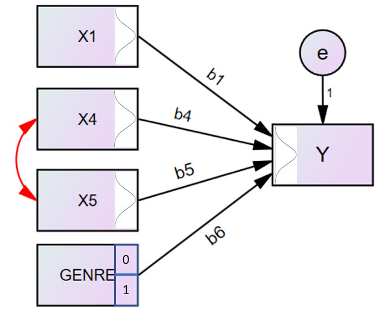

Figure 16.22: Modèle 5, impliquant les variables indépendantes X1, x4, x5 et Genre. La corrélation entre x4 et x5 est importante. L’objectif est d’examiner leur impact sur la variable dépendante y.

Modèle 5: Ajout de x1, x4, x5 et Genre

$$\operatorname{y} = {\color{blue}{\beta_{0}}} + {\color{blue}{\beta}}_{{\color{blue}{1}}}(\operatorname{Genre}) + {\color{blue}{\beta}}_{{\color{blue}{2}}}(\operatorname{x1}) + {\color{blue}{\beta}}_{{\color{blue}{3}}}(\operatorname{x4}) + {\color{blue}{\beta}}_{{\color{blue}{4}}}(\operatorname{x5}) + {\color{blue}{\epsilon}}$$

L’analyse de ce modèle fournit les résultats suivants:

$$\operatorname{\widehat{y}} = \underset{(18.038)}{60.678} + \underset{(5.734)}{18.283(\operatorname{Genre})} + \underset{(0.571)}{3.098(\operatorname{x1})} + \underset{(0.802)}{2.603(\operatorname{x4})} + \underset{(0.752)}{2.386(\operatorname{x5})}$$

```r
reg5 = lm(y ~ x1 + x4 + x5 + Genre, data = dat)
res5 = summary(reg5)

reg5 %>%
  tbl_regression(intercept = TRUE) %>%
  add_significance_stars(hide_ci = FALSE,
                         hide_p = FALSE) %>%
  bold_p() %>%
  add_glance_table(
    include = c("r.squared", "adj.r.squared", "df.residual",
                "sigma", "AIC", "BIC", "nobs"))
```

| **Characteristic** | **Beta**<sup>1</sup> | **SE**<sup>2</sup> | **95% CI**<sup>2</sup> | **p-value** |
| --- | --- | --- | --- | --- |
| (Intercept) | 61*** | 18.0 | 25, 96 | <0.001 |
| x1 | 3.1*** | 0.571 | 2.0, 4.2 | <0.001 |
| x4 | 2.6** | 0.802 | 1.0, 4.2 | 0.001 |
| x5 | 2.4** | 0.752 | 0.91, 3.9 | 0.002 |
| Genre | 18** | 5.73 | 7.0, 30 | 0.002 |
| R² | 0.249 |  |  |  |
| Adjusted R² | 0.239 |  |  |  |
| Residual df | 295 |  |  |  |
| Sigma | 48.2 |  |  |  |
| AIC | 3,184 |  |  |  |
| BIC | 3,206 |  |  |  |
| No. Obs. | 300 |  |  |  |

<sup>1</sup> *p<0.05; **p<0.01; ***p<0.001  
<sup>2</sup> SE = Standard Error, CI = Confidence Interval

Ces résultats indiquent que:

Ajoutant ce modèle au tableau Table 16.7, on trouve:

```r
r1 <- lm(y ~ Genre, data = dat)
r2 <- lm(y ~ Genre + x1, data = dat)
r3 <- lm(y ~ Genre + x1 + x4, data = dat)
r4 <- lm(y ~ Genre + x1 + x4 + x5, data = dat)
cmpmod <- data.frame("Modèle" = c("Genre", "Genre + X1", "Genre + X1 + X4", "Genre + x1 + x4 + x5"),
                     "R2 Simple" = cormat[1, c(7, 2, 5, 6)]^2,
                     "R2 Cumulatif" = cumsum(cormat[1, c(7, 2, 5, 6)]^2),
                     "R2 Cum Obs" = c(summary(r1)$r.squared,
                                      summary(r2)$r.squared,
                                      summary(r3)$r.squared,
                                      summary(r4)$r.squared)
                     )
rownames(cmpmod) <- NULL
cmpmod %>%
  kbl(digits = 3) %>%
  kable_styling(bootstrap_options = c("striped", "hover", "condensed"),
                full_width=FALSE) %>%
  column_spec(1, bold=TRUE, background="#89CFF0") %>%
  row_spec(0, bold=TRUE, background="#89CFF0")
```

Table 16.7: Comparaison entre les $R^2$ obtenus lors de régressions linéaires simples (**R2.Simple**), les $R^2$ que l’on obtiendrait lors de régressions multiples, si les variables indépendantes sont orthogonales (**R2.Cumulatif**), et les $R^2$ observés. tenant compte des corrélations existant entre les variables indépendantes (**R2.Cum.Obs**).

| Modèle | R2.Simple | R2.Cumulatif | R2.Cum.Obs |
| --- | --- | --- | --- |
| Genre | 0.021 | 0.021 | 0.021 |
| Genre + X1 | 0.055 | 0.075 | 0.084 |
| Genre + X1 + X4 | 0.135 | 0.210 | 0.224 |
| Genre + x1 + x4 + x5 | 0.130 | 0.340 | 0.249 |

De ce tableau, il est clair que la corrélation entre x4 et x5 met à mal l’additivité des contributions individuelles: le coefficient de détermination multiple observé diffère largement de la valeur que l’on obtiendrait si les variables indépendantes étaient orthogonales.

### 16.7.1 Comparaison des modèles

```r
models <- list(
  "Modèle 1" = lm(y ~ Genre, data = dat),
  "Modèle 2" = lm(y ~ x1, data = dat),
  "Modèle 3" = lm(y ~ x1 + Genre, data = dat),
  "Modèle 4" = lm(y ~ x1 + x4 + Genre, data = dat),
  "Modèle 5" = lm(y ~ x1 + x4 + x5 + Genre, data = dat))
modelsummary(models,
             title = "Paramètres des modèles étudiés",
             statistic = NULL,
             coef_rename = TRUE)
```

Paramètres des modèles étudiés

|  | Modèle 1 | Modèle 2 | Modèle 3 | Modèle 4 | Modèle 5 |
| --- | --- | --- | --- | --- | --- |
| (Intercept) | 223.794 | 181.874 | 165.668 | 75.133 | 60.678 |
| Genre | 16.307 |  | 19.575 | 18.957 | 18.283 |
| x1 |  | 2.619 | 2.842 | 2.992 | 3.098 |
| x4 |  |  |  | 4.339 | 2.603 |
| x5 |  |  |  |  | 2.386 |
| Num.Obs. | 300 | 300 | 300 | 300 | 300 |
| R2 | 0.021 | 0.055 | 0.084 | 0.224 | 0.249 |
| R2 Adj. | 0.018 | 0.051 | 0.078 | 0.216 | 0.239 |
| AIC | 3257.7 | 3247.2 | 3239.6 | 3192.0 | 3183.9 |
| BIC | 3268.8 | 3258.3 | 3254.4 | 3210.5 | 3206.1 |
| Log.Lik. | −1625.832 | −1620.584 | −1615.797 | −1590.985 | −1585.954 |
| F | 6.355 | 17.191 | 13.660 | 28.457 | 24.512 |
| RMSE | 54.63 | 53.68 | 52.83 | 48.64 | 47.83 |

On note que l’ajout de la variable x5 n’affecte que peu la valeur des coefficients liant $y$ à Genre ou x1. Cependant, le coefficient de x4 est lourdement affecté par cet ajout. Ce résultat indique que la valeur des coefficients de régressions varient en fonction du patron de corrélations entre les variables indépendantes. Plus les corrélations sont fortes, plus cet effet se fait sentir.

Les indices de qualité de l’ajustement (AIC, BIC, Log.Lik. et RMSE) indiquent que le modèle impliquant à la fois les quatre variables indépendantes (Modèle 5) est le plus performant, et correspond à celui qui devrait être retenu.

## 16.8 Prédicteurs à contributions faibles

Les variables Genre et x1 se sont avérées utiles pour expliquer une portion intéressante de la variance de $y$. Mais quel serait l’impact de l’ajout de variables faiblement corrélées avec la variable dépendante? Pour répondre à cette question, considérons les variables x2 et x3, présentes dans la matrice de données. De la matrice de corrélations affichée à la figure Figure 16.1, on note que $r_{y, x2}=-0.086$ et que $r_{y, x3}=-0.098$, ces deux corrélations n’étant pas significativement différentes de 0. On ne s’attend donc pas à ce que les variables x2 et x3 aient une contribution significative à la régression. Notons également, que ces variables ne sont que faiblement corrélées avec les autres variables indépendantes. Cependant, quelles observations peut-on faire suire à leur inclusion dans le modèle, représenté graphiquement dans la figure Figure 16.23 :

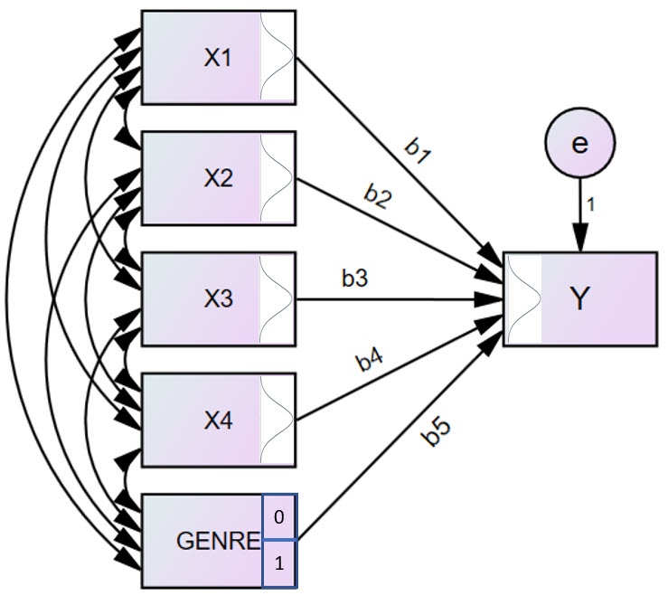

Figure 16.23: Modèle 5, impliquant les variables indépendantes X1-x4, et Genre.

Modèle 5: Ajout de variables de faible contribution

$$\operatorname{y} = {\color{blue}{\beta_{0}}} + {\color{blue}{\beta}}_{{\color{blue}{1}}}(\operatorname{Genre}) + {\color{blue}{\beta}}_{{\color{blue}{2}}}(\operatorname{x1}) + {\color{blue}{\beta}}_{{\color{blue}{3}}}(\operatorname{x2}) + {\color{blue}{\beta}}_{{\color{blue}{4}}}(\operatorname{x3}) + {\color{blue}{\beta}}_{{\color{blue}{5}}}(\operatorname{x4}) + {\color{blue}{\epsilon}}$$

L’analyse de ce modèle fournit les résultats suivants:

$$\operatorname{\widehat{y}} = \underset{(24.859)}{111.663} + \underset{(5.793)}{18.722(\operatorname{Genre})} + \underset{(0.576)}{2.955(\operatorname{x1})} - \underset{(0.587)}{0.605(\operatorname{x2})} - \underset{(0.59)}{1.162(\operatorname{x3})} + \underset{(0.593)}{4.321(\operatorname{x4})}$$

```r
reg5 <- lm(y ~ Genre + x1 + x2 + x3 + x4, data = dat)
res5 <- summary(reg5)

reg5 %>%
  tbl_regression(intercept = TRUE) %>%
  add_significance_stars(hide_ci = FALSE,
                         hide_p = FALSE) %>%
  bold_p() %>%
  add_glance_table(
    include = c("r.squared", "adj.r.squared", "df.residual",
                "sigma", "AIC", "BIC", "nobs"))
```

| **Characteristic** | **Beta**<sup>1</sup> | **SE**<sup>2</sup> | **95% CI**<sup>2</sup> | **p-value** |
| --- | --- | --- | --- | --- |
| (Intercept) | 112*** | 24.9 | 63, 161 | <0.001 |
| Genre | 19** | 5.79 | 7.3, 30 | 0.001 |
| x1 | 3.0*** | 0.576 | 1.8, 4.1 | <0.001 |
| x2 | -0.61 | 0.587 | -1.8, 0.55 | 0.3 |
| x3 | -1.2* | 0.590 | -2.3, 0.00 | 0.050 |
| x4 | 4.3*** | 0.593 | 3.2, 5.5 | <0.001 |
| R² | 0.237 |  |  |  |
| Adjusted R² | 0.224 |  |  |  |
| Residual df | 294 |  |  |  |
| Sigma | 48.7 |  |  |  |
| AIC | 3,191 |  |  |  |
| BIC | 3,217 |  |  |  |
| No. Obs. | 300 |  |  |  |

<sup>1</sup> *p<0.05; **p<0.01; ***p<0.001  
<sup>2</sup> SE = Standard Error, CI = Confidence Interval

```r
models <- list(
  "Modèle 1" = lm(y ~ Genre, data = dat),
  "Modèle 2" = lm(y ~ x1, data = dat),
  "Modèle 3" = lm(y ~ x1 + Genre, data = dat),
  "Modèle 4" = lm(y ~ x1 + x4 + Genre, data = dat),
  "Modèle 5" = lm(y ~ x1 + x2 + x3 + x4 + Genre, data = dat))
modelsummary(models,
             title = "Paramètres des modèles étudiés",
             statistic = NULL,
             coef_rename = TRUE)
```

Paramètres des modèles étudiés

|  | Modèle 1 | Modèle 2 | Modèle 3 | Modèle 4 | Modèle 5 |
| --- | --- | --- | --- | --- | --- |
| (Intercept) | 223.794 | 181.874 | 165.668 | 75.133 | 111.663 |
| Genre | 16.307 |  | 19.575 | 18.957 | 18.722 |
| x1 |  | 2.619 | 2.842 | 2.992 | 2.955 |
| x4 |  |  |  | 4.339 | 4.321 |
| x2 |  |  |  |  | −0.605 |
| x3 |  |  |  |  | −1.162 |
| Num.Obs. | 300 | 300 | 300 | 300 | 300 |
| R2 | 0.021 | 0.055 | 0.084 | 0.224 | 0.237 |
| R2 Adj. | 0.018 | 0.051 | 0.078 | 0.216 | 0.224 |
| AIC | 3257.7 | 3247.2 | 3239.6 | 3192.0 | 3191.0 |
| BIC | 3268.8 | 3258.3 | 3254.4 | 3210.5 | 3216.9 |
| Log.Lik. | −1625.832 | −1620.584 | −1615.797 | −1590.985 | −1588.511 |
| F | 6.355 | 17.191 | 13.660 | 28.457 | 18.219 |
| RMSE | 54.63 | 53.68 | 52.83 | 48.64 | 48.24 |

## 16.9 Variable indépendante corrélée avec l’erreur

Dans plusieurs circonstances, une variable indépendante X est corrélée avec une variable Z qui n’est pas représentée dans le modèle. La portion de la variance de Y qui pourrait s’expliquer par Z se trouve donc composante de la variance d’erreur et en conséquence, X est corrélée avec le terme d’erreur: elle est dite **endogène**.

Pour illustrer, considérons le code R suivant. On génère aléatoirement 1000 observations pour deux variables indépendantes (X1 et X2) et un terme d’erreur (e). Or, e est un déterminant de X2 (au moins une de ses composantes est corrélée avec X2). X1 et X2 sont ensuite régressées sur Y, la variable dépendante.

```r
e <- rnorm(1000)                  # Erreur aléatoire, N(0, 1)
X1 <- rnorm(1000)                 # X1, N(0, 1)
X2 <- rnorm(1000) + 1 * e         # X2 corrélé avec e

Y <- 1 + 1 * X1 - 1 * X2 + 2 * e  # Modèle au niveau de la population

reg <- lm(Y ~ X1 + X2)            # Régression de X1 et X2 sur Y
summary(reg)$coefficients         # Affichage des résultats
```

```
#>               Estimate Std. Error   t value     Pr(>|t|)
#> (Intercept)  1.0930840 0.04598192 23.772040 2.551675e-99
#> X1           0.9997982 0.04510591 22.165571 8.012781e-89
#> X2          -0.0569818 0.03076042 -1.852439 6.425823e-02
```

On note que l’intercept et le coefficient de X1 sont três près des véritables paramètres de la population qui leur correspondent. Cependant, le coefficient de X2, égal à -1.0 au niveau de la population s’en éloigne grandement. On trouve donc que la corrélation entre une variable indépendante et le terme d’erreur a pour effet d’introduire un biais dans la valeur du coefficient de régression associé à cette variable.

## 16.10 Variables indépendantes corrélées

Dans les modèles développés dans les sections précédentes, les corrélations entre les variables indépendantes n’étaient que faiblement corrélées entre elles. On a pu observer que dans un tel cas, la proportion de la variance de la variable dépendante expliquée par la combinaison linéaire des variables indépendantes ($R^2$: *coefficient de détermination multiple*) est approximativement égale à la somme des coefficients de détermination ($r^2$) que l’on obtiendrait de régressions n’impliquant qu’une variable indépendante à la fois. L’égalité serait parfaite si les variables indépendantes étaient orthogonales l’une par rapport à l’autre.

Dans la section Section 16.7, on a pu constater qu’une corrélation entre variables indépendantes suffit à rompre cette additivité et à modifier la valeur des coefficients de régression liés à ces variables. On peut aisément concevoir que l’ajout de variables indépendantes corrélées dans un modèle de régression est susceptible d’introduire une certaine confusion, du fait que ces variables partagent elles-mêmes des portions de leurs propres variances. C’est généralement le cas que les variables indépendantes sont plus ou moins corrélées l’une avec les autres. Dans certains cas, il s’agit de corrélations simples, alors que dans plusieurs situations, il s’agit de corrélations entre une variable indépendante et une combinaison linéaire impliquant d’autres variables indépendantes. Ces corrélations n’empêchent en rien une analyse de régression et n’en affectent aucunement la validité. Cependant, des corrélations très fortes ont des conséquences importantes, et des corrélations parfaites rendent impossible l’estimation des paramètres. Pour concrétiser cette situation, considérons l’ajout de la variable x6 au modèle 4, impliquant Genre, x1 et x4:

Modèle 6: Ajout de Genre, x1, x4 et x6

$$\operatorname{y} = {\color{blue}{\beta_{0}}} + {\color{blue}{\beta}}_{{\color{blue}{1}}}(\operatorname{Genre}) + {\color{blue}{\beta}}_{{\color{blue}{2}}}(\operatorname{x1}) + {\color{blue}{\beta}}_{{\color{blue}{3}}}(\operatorname{x4}) + {\color{blue}{\beta}}_{{\color{blue}{4}}}(\operatorname{x6}) + {\color{blue}{\epsilon}}$$

L’analyse de ce modèle fournit les résultats suivants:

$$\operatorname{\widehat{y}} = 115.93 + 18.86(\operatorname{Genre}) + 2.95(\operatorname{x1}) + 4.45(\operatorname{x4}) - 2.11(\operatorname{x6})$$

```r
reg6 <- lm(y ~ Genre + x1 + x4 + x6,
           data = dat)
res6 <- summary(reg6)

reg6 %>%
  tbl_regression(intercept = TRUE) %>%
  add_significance_stars(hide_ci = FALSE,
                         hide_p = FALSE) %>%
  bold_p() %>%
  add_glance_table(
    include = c("r.squared", "adj.r.squared", "df.residual",
                "sigma", "AIC", "BIC", "nobs")) %>%
  add_vif()
```

| **Characteristic** | **Beta**<sup>1</sup> | **SE**<sup>2</sup> | **95% CI**<sup>2</sup> | **p-value** | **VIF**<sup>2</sup> |
| --- | --- | --- | --- | --- | --- |
| (Intercept) | 116*** | 20.3 | 76, 156 | <0.001 |  |
| Genre | 19** | 5.69 | 7.7, 30 | 0.001 | 1.0 |
| x1 | 2.9*** | 0.566 | 1.8, 4.1 | <0.001 | 1.0 |
| x4 | 4.5*** | 0.582 | 3.3, 5.6 | <0.001 | 1.0 |
| x6 | -2.1*** | 0.549 | -3.2, -1.0 | <0.001 | 1.0 |
| R² | 0.261 |  |  |  |  |
| Adjusted R² | 0.251 |  |  |  |  |
| Residual df | 295 |  |  |  |  |
| Sigma | 47.9 |  |  |  |  |
| AIC | 3,179 |  |  |  |  |
| BIC | 3,202 |  |  |  |  |
| No. Obs. | 300 |  |  |  |  |

<sup>1</sup> *p<0.05; **p<0.01; ***p<0.001  
<sup>2</sup> SE = Standard Error, CI = Confidence Interval, VIF = Variance Inflation Factor

Une colonne affichant un nouvel indice, **VIF** (*Variance Inflation Factor*)) s’ajoute à ce tableau. Il s’agit d’une mesure de l’impact de la collinéarité (corrélations entre variables indépendantes) sur la dispersion de la distributon d’échantillonnage des coefficients de régression. En effet, les corrélations entre variables indépendantes ont un impact direct sur ces erreurs-standards. Pour le présent modèle, tous les **VIFs** sont égaux à 1.0, ce qui est désirable: les variables sont approximativement orthogonales.

Maintenant, ajoutons les variables x7 et x8, deux variables qui sont fortement reliées à x6:

Modèle 7: Ajout de Genre, x1, x4, x6, x7 et x8

$$\operatorname{y} = {\color{blue}{\beta_{0}}} + {\color{blue}{\beta}}_{{\color{blue}{1}}}(\operatorname{Genre}) + {\color{blue}{\beta}}_{{\color{blue}{2}}}(\operatorname{x1}) + {\color{blue}{\beta}}_{{\color{blue}{3}}}(\operatorname{x4}) + {\color{blue}{\beta}}_{{\color{blue}{4}}}(\operatorname{x6}) + {\color{blue}{\beta}}_{{\color{blue}{5}}}(\operatorname{x7}) + {\color{blue}{\beta}}_{{\color{blue}{6}}}(\operatorname{x8}) + {\color{blue}{\epsilon}}$$

$$\operatorname{y} = {\color{blue}{\beta_{0}}} + {\color{blue}{\beta}}_{{\color{blue}{1}}}(\operatorname{Genre}) + {\color{blue}{\beta}}_{{\color{blue}{2}}}(\operatorname{x1}) + {\color{blue}{\beta}}_{{\color{blue}{3}}}(\operatorname{x4}) + {\color{blue}{\beta}}_{{\color{blue}{4}}}(\operatorname{x6}) + {\color{blue}{\beta}}_{{\color{blue}{5}}}(\operatorname{x7}) + {\color{blue}{\beta}}_{{\color{blue}{6}}}(\operatorname{x8}) + {\color{blue}{\epsilon}}$$
L’analyse de ce modèle produit les résultats suivants:

$$\operatorname{\widehat{y}} = \underset{(20.555)}{113.262} + \underset{(5.709)}{18.77(\operatorname{Genre})} + \underset{(0.567)}{2.988(\operatorname{x1})} + \underset{(0.583)}{4.49(\operatorname{x4})} - \underset{(1.464)}{2.164(\operatorname{x6})} + \underset{(1.394)}{1.748(\operatorname{x7})} - \underset{(1.504)}{1.635(\operatorname{x8})}$$

```r
reg7 <- lm(y ~ Genre + x1 + x4  + x6 + x7 + x8,
           data = dat)
res7 <- summary(reg7)

reg7 %>%
  tbl_regression(intercept = TRUE) %>%
  add_significance_stars(hide_ci = FALSE,
                         hide_p = FALSE) %>%
  bold_p() %>%
  add_glance_table(
    include = c("r.squared", "adj.r.squared", "df.residual",
                "sigma", "AIC", "BIC", "nobs")) %>%
  add_vif()
```

| **Characteristic** | **Beta**<sup>1</sup> | **SE**<sup>2</sup> | **95% CI**<sup>2</sup> | **p-value** | **VIF**<sup>2</sup> |
| --- | --- | --- | --- | --- | --- |
| (Intercept) | 113*** | 20.6 | 73, 154 | <0.001 |  |
| Genre | 19** | 5.71 | 7.5, 30 | 0.001 | 1.0 |
| x1 | 3.0*** | 0.567 | 1.9, 4.1 | <0.001 | 1.0 |
| x4 | 4.5*** | 0.583 | 3.3, 5.6 | <0.001 | 1.0 |
| x6 | -2.2 | 1.46 | -5.0, 0.72 | 0.14 | 7.1 |
| x7 | 1.7 | 1.39 | -1.0, 4.5 | 0.2 | 6.0 |
| x8 | -1.6 | 1.50 | -4.6, 1.3 | 0.3 | 7.2 |
| R² | 0.266 |  |  |  |  |
| Adjusted R² | 0.251 |  |  |  |  |
| Residual df | 293 |  |  |  |  |
| Sigma | 47.9 |  |  |  |  |
| AIC | 3,181 |  |  |  |  |
| BIC | 3,211 |  |  |  |  |
| No. Obs. | 300 |  |  |  |  |

<sup>1</sup> *p<0.05; **p<0.01; ***p<0.001  
<sup>2</sup> SE = Standard Error, CI = Confidence Interval, VIF = Variance Inflation Factor

Cette fois, les facteurs d’inflation de la variance ont pris des valeurs élevées pour les variables x6, x7 et x8, mettant en évidence les relations qu’elles entretiennent. Notons également les valeurs des erreurs-standards des coefficients liés à ces variables: elles peuvent sembler trop élevées, se rapprochant de la valeur du coefficient correspondant, qu’elles pourraient même dépasser.

Comparons ces résultats:

```r
models <- list(
  "Modèle 5" = lm(y ~ Genre + x1 + x4, data = dat),
  "Modèle 6a" = lm(y ~ Genre + x1 + x4 + x6, data = dat),
  "Modèle 6b" = lm(y ~ Genre + x1 + x4 + x7, data = dat),
  "Modèle 6c" = lm(y ~ Genre + x1 + x4 + x8, data = dat),
  "Modèle 7" = lm(y ~ Genre + x1 + x4 + x6 + x7 + x8, data = dat))
modelsummary(models,
             title = "Paramètres des modèles étudiés",
             statistic = NULL,
             coef_rename = TRUE)
```

Paramètres des modèles étudiés

|  | Modèle 5 | Modèle 6a | Modèle 6b | Modèle 6c | Modèle 7 |
| --- | --- | --- | --- | --- | --- |
| (Intercept) | 75.133 | 115.927 | 108.076 | 113.396 | 113.262 |
| Genre | 18.957 | 18.855 | 19.462 | 19.510 | 18.770 |
| x1 | 2.992 | 2.948 | 2.965 | 3.009 | 2.988 |
| x4 | 4.339 | 4.452 | 4.424 | 4.496 | 4.490 |
| x6 |  | −2.109 |  |  | −2.164 |
| x7 |  |  | −1.721 |  | 1.748 |
| x8 |  |  |  | −2.104 | −1.635 |
| Num.Obs. | 300 | 300 | 300 | 300 | 300 |
| R2 | 0.224 | 0.261 | 0.247 | 0.259 | 0.266 |
| R2 Adj. | 0.216 | 0.251 | 0.237 | 0.249 | 0.251 |
| AIC | 3192.0 | 3179.4 | 3184.9 | 3180.1 | 3181.4 |
| BIC | 3210.5 | 3201.6 | 3207.2 | 3202.3 | 3211.0 |
| Log.Lik. | −1590.985 | −1583.676 | −1586.469 | −1584.044 | −1582.688 |
| F | 28.457 | 26.015 | 24.175 | 25.771 | 17.662 |
| RMSE | 48.64 | 47.46 | 47.91 | 47.52 | 47.31 |

De ce tableau, on note que les coefficients liant y à x7 et x8 varient dans le modèle 7, par rapport à ceux obtenus en l’absence de collinéarité. Il s’agit d’un fait avéré que la multicollinéarité se traduit par des variations importantes au niveau des coefficients liés aux variables colinéaires.

## 16.11 Importance relative des prédicteurs

Lorsque plusieurs variables indépendantes sont introduites dans un modèle de régression, il est généralement intéressant de déterminer l’importance de la contribution de chacune d’elles à la régression. Plusieurs indices existent dans ce contexte. Les coefficients de régression standardisés en font partie. Essentiellement, il s’agit des coefficients obtenus à partir des données centrées et réduites (scores Z) pour l’ensemble des variables. Pour le model 7, analysé à la section précédente, on trouve:

```r
reg7b <- lm.beta(reg7)
reg7b
```

```
#>      Genre         x1         x4         x6         x7         x8
#>  0.1663337  0.2664146  0.3870007 -0.1974338  0.1543538 -0.1459740
```

Ces coefficients étant standardisés, ils sont directement comparables l’un à l’autre. On considère donc x4 comme étant la variable contribuant le plus à la régression, suivie de x1. Cette indication est précieuse, mais ne nous informe pas sur la contribution de la variable au $R^2$.

[Ulrike Groemping & Lehrkamp (2006)](https://www.jstatsoft.org/article/view/v017i01) ont produit une librairie R permettant d’obtenir différents indices de l’importance de la contribution des variables indépendantes dans un modèle de régression linéaire. [Ulrike Groemping (2015)](https://wires.onlinelibrary.wiley.com/doi/epdf/10.1002/wics.1346) présente les détails de ces procédures et en fournit des exemples. Appliquant ces procédures au modèle 7, on obtient le tableau suivant:

```r
calc.relimp(reg7,
            type = c("lmg", "betasq", "last", "first", "pratt"),
            rela = FALSE)
```

[output not shown]

```r
calc.relimp(reg7,
            type = c("lmg"),
            rela = TRUE)
```

[output not shown]

## 16.12 Régression logistique

La figure Figure 16.24 représente un modèle de régression logistique, la variable dépendante $y$ étant de nature dichotomique (0/1, échec/succès, …). Les variable indépendantes peuvent être de toute nature.

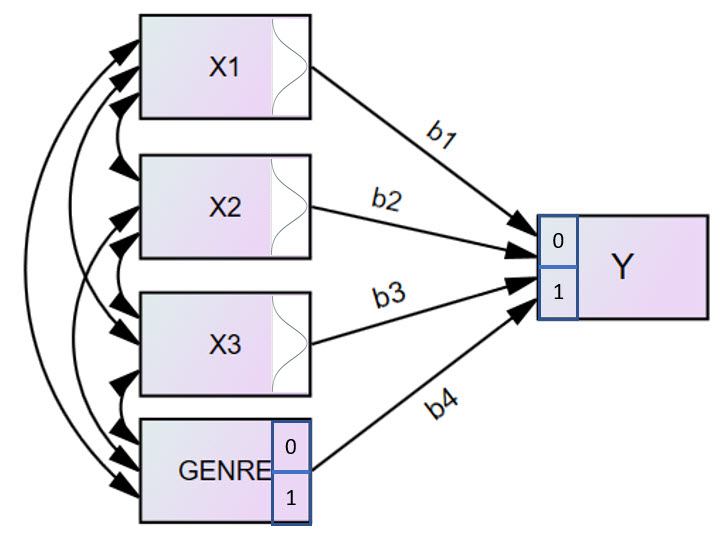

Figure 16.24: Modèle de régression logistique, impliquant les variables indépendantes X1-x3, et Genre. La variable dépendante est dichotomique

## 16.13 Régression multinomiale

La figure Figure 16.25 représente un modèle de régression multinomiale, la variable dépendante $y$ étant de nature polytomique (catégories ‘a’, ‘b’, ‘c’, …). Les variable indépendantes peuvent être de toute nature.

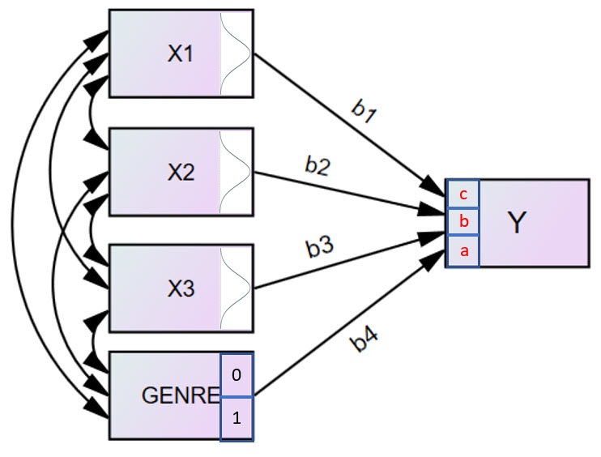

Figure 16.25: Modèle de régression multinomiale, impliquant les variables indépendantes X1-x3, et Genre. La variable dépendante est polytomique

## 16.14 Régression ordinale

La figure Figure 16.26 représente un modèle de régression ordinale, la variable dépendante $y$ étant composées de $k$ catégories ordonnées (catégories ‘1’, ‘2’, ‘3’, …). Les variable indépendantes peuvent être de toute nature.

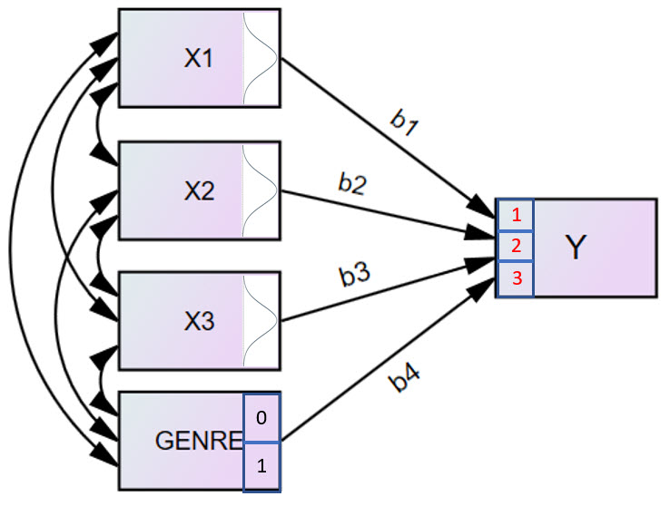

Figure 16.26: Modèle de régression ordinale, impliquant les variables indépendantes X1-x3, et Genre. La variable dépendante est ordinale